# MixTox_Transcriptomics_Downstream_Analysis

Vaskar Mukherjee

9/9/2021

# TRANSCRIPTOMIC ANALYSIS

In this project we used high‐throughput phenomics to identify synergistic or antagonistic interactions in chemical mixtures in the yeast Saccharomyces cerevisiae and Debaryomyces hansenii and used transcriptomic analysis to understand the mechanistic basis of the interactions.

Transcriptomics analysis to understand the mechanistic basis of chemical interactions was performed for two chemical interactions for growth rate (growth during the exponential growth phase), identified in our phenomics experiment, that were conserved in both species i.e. NaCl and rapamycin synergism, and salt and paraquat antagonism.

The details of the transcriptomic samples are given in **COMPILED_DATA/SAMPLE_DETAILS.xlsx**

- **UPSTREAM ANALYSIS**

We used the alignment program, HISAT2 (version 2.1.0) [Kim, 2015](https://doi.org/10.1038/nmeth.3317) for mapping next-generation sequencing reads with the reference sequence. Preprocessing of RNA-seq alignments for differential expression calling was performed afterwards using the Python package HTSeq (version 0.11.1) [Anders, 2014](https://doi.org/10.1093/bioinformatics/btu638). The UPSTREAM ANALYSIS RESULTS has been described in details in the [Git_folder](https://github.com/mukherjeevaskar267/Mixtox_transcriptomics/tree/main/UPSTREAM_ANALYSIS)

- **DOWNSTREAM ANALYSIS**

Downstream analysis to identify deferentially expressed genes was performed using the R package DESeq2 (version 1.30.1) [Love, 2014](https://doi.org/10.1186/s13059-014-0550-8).

## INSTALL PACKAGES

The following packages will be frequently used for the entire data analysis and visualization

- ggplot2
- DESeq2
- pheatmap
- RColorBrewer

## IMPORT DATA

- STEP1 : Save the path of the HTSeq output folder in a variable

```r
#for cerevisiae
Dir_sc <- "RAW_COUNT_DATA/HTSEQ_SC/"

#for hansenii
Dir_dh <- "RAW_COUNT_DATA/HTSEQ_DH/"
```

- STEP2 : Create a sample table with 3 columns. First column should be “sampleName” i.e. the name identifier of the samples. The second column should be “fileName” i.e. the file name list in this htseq output folder with the correct extentions, and the third column should be condition i.e. the treatment condition. The column names should be exactly same without the quotations. This is necessary for the functions to work properly. You can create this table in excel and then copy paste it in a .txt object. Later it can be read by the read.table function.

```r
#for cerevisiae
sampleinfo_sc <- read.table("COMPILED_DATA/sampleTable_SC.txt", header = TRUE, sep = "\t", as.is = TRUE)

#for hansenii
sampleinfo_dh <- read.table("COMPILED_DATA/sampleTable_DH.txt", header = TRUE, sep = "\t", as.is = TRUE)
```

- STEP3 : Create the sampleTable object for both dataset

```r
#for cerevisiae
sampleTable_sc <- data.frame(sampleName = sampleinfo_sc$sampleName,
                          fileName = sampleinfo_sc$fileName,
                          condition = sampleinfo_sc$condition)

#for hansenii
sampleTable_dh <- data.frame(sampleName = sampleinfo_dh$sampleName,
                          fileName = sampleinfo_dh$fileName,
                          condition = sampleinfo_dh$condition)
```

- STEP4 : Build the DESeqDataSet

```r
library(DESeq2)
#for cerevisiae
ddsHTSeq_sc <- DESeqDataSetFromHTSeqCount(sampleTable = sampleTable_sc,
                                       directory = Dir_sc,
                                       design= ~ condition)

#for hansenii
ddsHTSeq_dh <- DESeqDataSetFromHTSeqCount(sampleTable = sampleTable_dh,
                                       directory = Dir_dh,
                                       design= ~ condition)
```

- STEP5 : Print the object

```r
#for cerevisiae
ddsHTSeq_sc
```

```
## class: DESeqDataSet
## dim: 7445 18
## metadata(1): version
## assays(1): counts
## rownames(7445): 15S_rRNA 21S_rRNA ... tY(GUA)O tY(GUA)Q
## rowData names(0):
## colnames(18): 1_Sc_C1 2_Sc_C2 ... 17_Sc_SR2 18_Sc_SR3
## colData names(1): condition
```

```r
#for hansenii
ddsHTSeq_dh
```

```
## class: DESeqDataSet
## dim: 6712 21
## metadata(1): version
## assays(1): counts
## rownames(6712): DEHA2A00110g DEHA2A00132g ... ENSRNAG049932294
##   ENSRNAG049932295
## rowData names(0):
## colnames(21): 19_Dh_C1 20_Dh_C2 ... 38_Dh_SR2 39_Dh_SR3
## colData names(1): condition
```

## PRE-FILTERING

```r
#for cerevisiae
keep<-rowSums(counts(ddsHTSeq_sc)) >= 10
dds_SC<-ddsHTSeq_sc[keep, ]
dds_SC_LOST<-ddsHTSeq_sc[!keep, ]
#for hansenii
keep<-rowSums(counts(ddsHTSeq_dh)) >= 10
dds_DH<-ddsHTSeq_dh[keep, ]
dds_DH_LOST<-ddsHTSeq_dh[!keep, ]
```

## DATA-TRANSFORMATION

Data-transformation functions within DESeq2 are provided for applications other than differential testing, for example clustering of samples or other machine learning applications. Those are the ntd (shifted logarithm), rlog (regularized logarithm) and vst (variance stabilizing transformation). The shifted logarithm has elevated standard deviation in the lower count range, and the regularized log to a lesser extent, while for the variance stabilized data the standard deviation is roughly constant along the whole dynamic range. Note that the vertical axis in such plots is the square root of the variance over all samples, so including the variance due to the experimental conditions. While a flat curve of the square root of variance over the mean may seem like the goal of such transformations, this may be unreasonable in the case of datasets with many true differences due to the experimental conditions.

```r
#for cerevisiae
rld_sc <- rlogTransformation(dds_SC)
vsd_sc <- varianceStabilizingTransformation(dds_SC)
ntd_sc <- normTransform(dds_SC)
#for hansenii
rld_dh <- rlogTransformation(dds_DH)
vsd_dh <- varianceStabilizingTransformation(dds_DH)
ntd_dh <- normTransform(dds_DH)
```

## DATA-VISUALIZATION 1: Effects of transformations on the variance

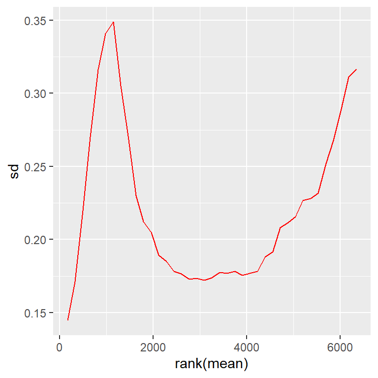

Figure 1A: Effects of transformations on the variance, S. cerevisiae and rld transformation

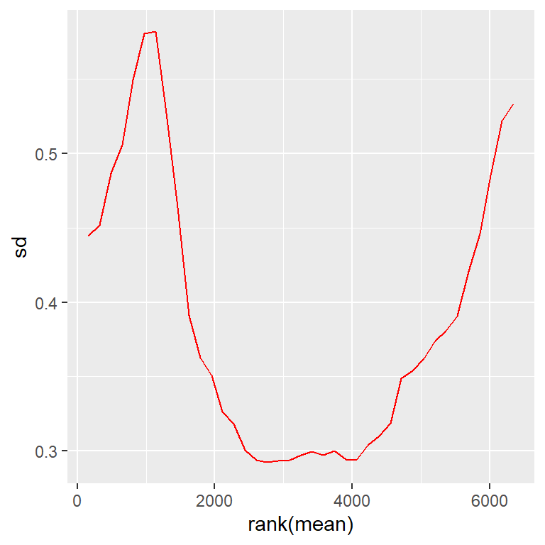

Figure 1B: Effects of transformations on the variance, S. cerevisiae and vsd transformation

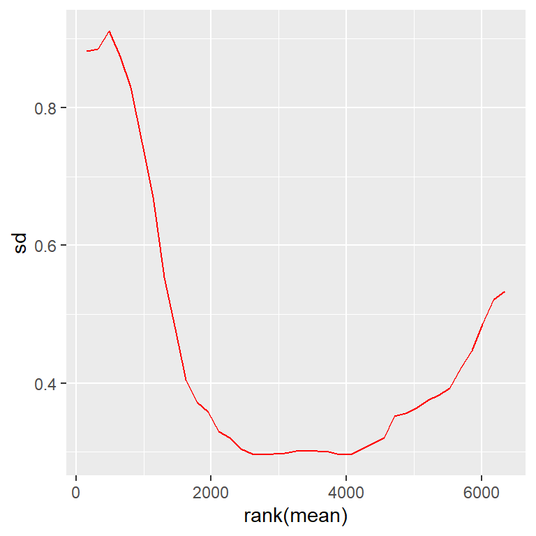

Figure 1C: Effects of transformations on the variance, S. cerevisiae and ntd transformation

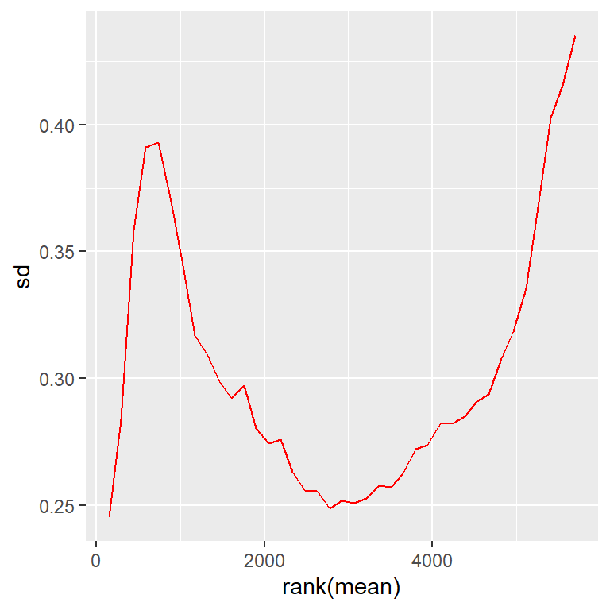

Figure 2A: Effects of transformations on the variance, D. hansenii and rld transformation

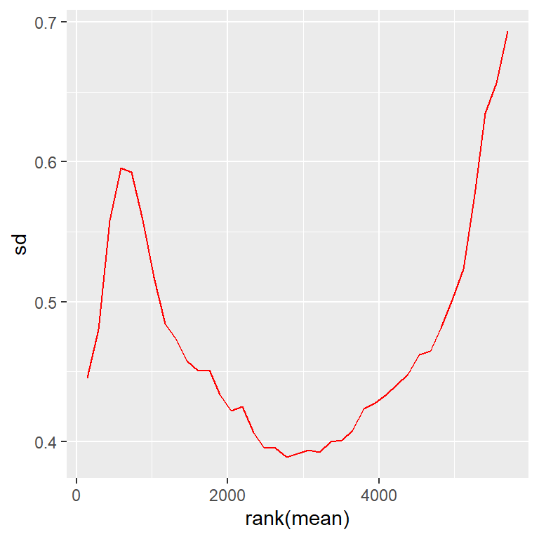

Figure 2B: Effects of transformations on the variance, D. hansenii and vsd transformation

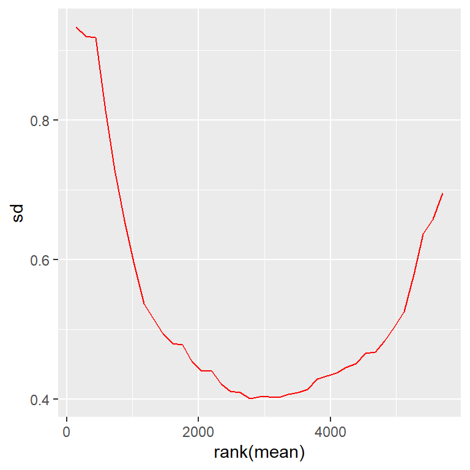

Figure 2C: Effects of transformations on the variance, D. hansenii and ntd transformation

## DATA-VISUALIZATION 2: Plotting PCA

The above analysis shows that the rld data transformation is most suitable for our dataset. Therefore from now on all analysis will be with the rld dataset

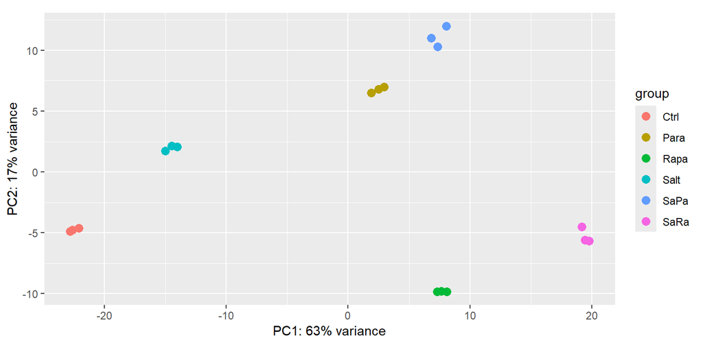

Figure 3: PCA plot, rld and S. cerevisiae

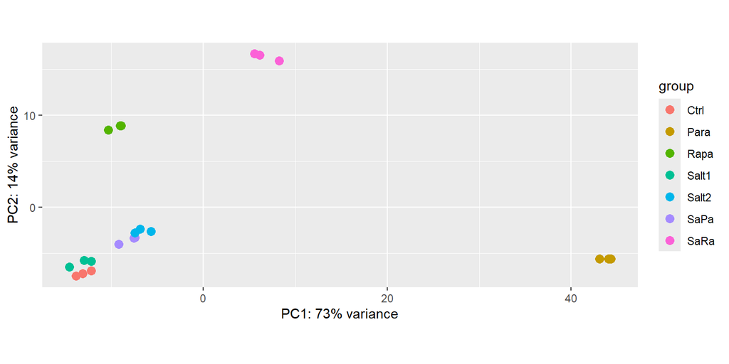

Figure 4: PCA plot, rld and D. hansenii

## DATA-VISUALIZATION 3 > SIMILARITY MATRIX

Calculation of the euclidean distance of the transformed data. We need to transpose the data since we want to calculate the distance between samples rather than among genes. So we need the samples as rows rather than columns

```r
library(DESeq2)
library(pheatmap)
library(RColorBrewer)
#for cerevisiae
sampleDists_SC <- dist(t(assay(rld_sc)))
#Creating the corresponding matrix
sampleDistMatrix_SC <- as.matrix(sampleDists_SC)
#creating a distance matrix tagging the groups of the samples
sample_data_sc<-data.frame(Group=sampleinfo_sc$condition)
row.names(sample_data_sc)<-sampleinfo_sc$sampleName
#defining the colors we want to use depending on the condition
annotation_sc <- list(Group = c(Ctrl="green", Para="brown", Rapa="red", Salt="cyan", SaPa="blue", SaRa="magenta"))

#for hansenii
sampleDists_DH <- dist(t(assay(rld_dh)))
#Creating the corresponding matrix
sampleDistMatrix_DH <- as.matrix(sampleDists_DH)
#creating a distance matrix tagging the groups of the samples
sample_data_dh<-data.frame(Group=sampleinfo_dh$condition)
row.names(sample_data_dh)<-sampleinfo_dh$sampleName
#defining the colors we want to use depending on the condition
annotation_dh <- list(Group = c(Ctrl="green", Para="brown", Rapa="red", Salt1="cyan", Salt2="turquoise4", SaPa="blue", SaRa="magenta"))

#Make a color palette for heatmap
colfunc<-colorRampPalette(c("goldenrod4", "goldenrod", "white", "turquoise", "turquoise4"))
```

Plotting the heatmap for cerevisiae

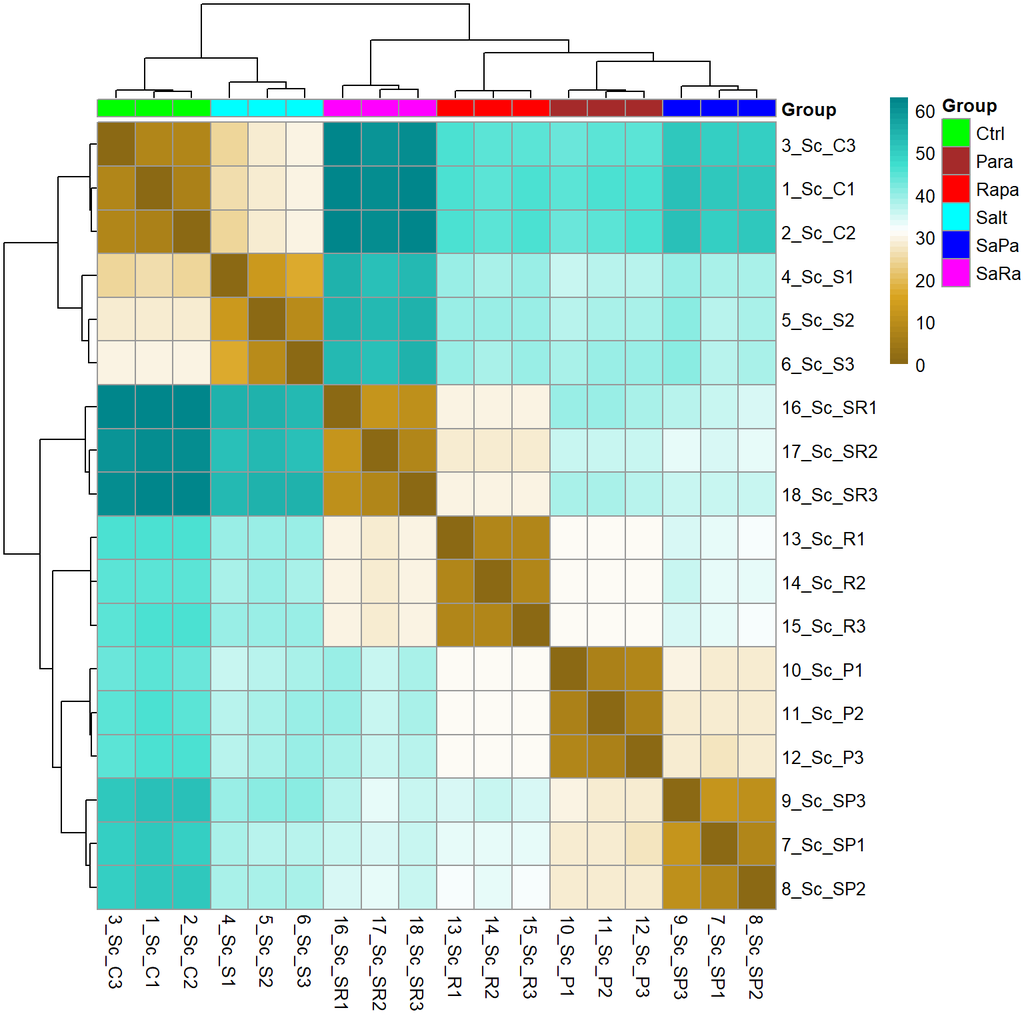

Figure 5: Similarity matrix, rld and S. cerevisiae

Plotting the heatmap for hansenii

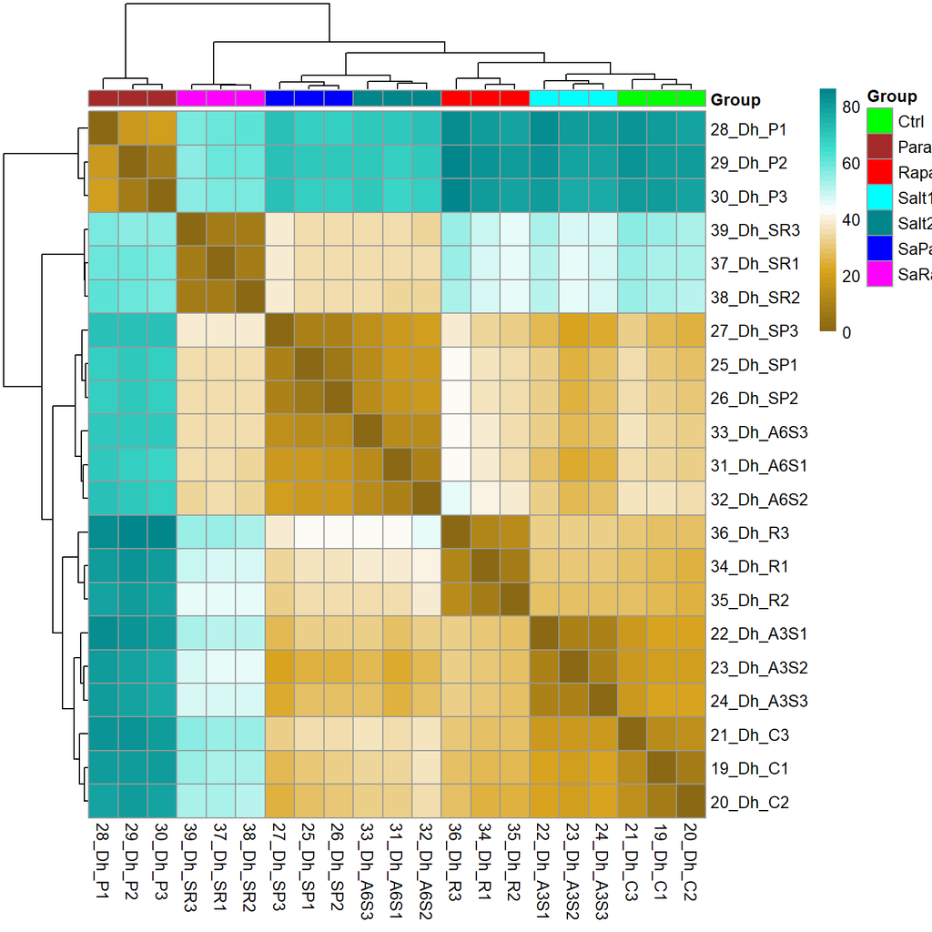

Figure 6: Similarity matrix, rld and D. hansenii

## DIFFERENTIALLY EXPRESSED GENES (DEGs) ANALYSIS

The standard differential expression analysis steps are wrapped into a single function, DESeq.The estimation steps performed by this function are described in the Methods section of the DESeq2 publication [Love, 2014](https://doi.org/10.1186/s13059-014-0550-8).

For differential testing it is recommended to use the DESeq function applied directly to the raw counts.

```r
#for cerevisiae
dds_T_SC <- DESeq(dds_SC)
#for hansenii
dds_T_DH <- DESeq(dds_DH)
```

### DEGs COMPARED TO CONTROL (FOR CEREVISIAE)

- **STEP1**:Data Preparation

```r
#differential expression Salt vs Ctrl
res_SC_Salt <-results(dds_T_SC, contrast=c("condition", "Salt", "Ctrl"))
#differential expression Para vs Ctrl
res_SC_Para <-results(dds_T_SC, contrast=c("condition", "Para", "Ctrl"))
#differential expression SaPa vs Ctrl
res_SC_SaPa <-results(dds_T_SC, contrast=c("condition", "SaPa", "Ctrl"))
#differential expression Rapa vs Ctrl
res_SC_Rapa <-results(dds_T_SC, contrast=c("condition", "Rapa", "Ctrl"))
#differential expression SaRa vs Ctrl
res_SC_SaRa <-results(dds_T_SC, contrast=c("condition", "SaRa", "Ctrl"))
#differential expression SaPa vs Salt
res_SC_MX_SaPavsSalt <-results(dds_T_SC, contrast=c("condition", "SaPa", "Salt"))
#differential expression SaPa vs Para
res_SC_MX_SaPavsPara <-results(dds_T_SC, contrast=c("condition", "SaPa", "Para"))
#differential expression SaRa vs Salt
res_SC_MX_SaRavsSalt <-results(dds_T_SC, contrast=c("condition", "SaRa", "Salt"))
#differential expression SaRa vs Rapa
res_SC_MX_SaRavsRapa <-results(dds_T_SC, contrast=c("condition", "SaRa", "Rapa"))
```

- **STEP2**:Making the dataframe

```r
salt_SC<-data.frame(res_SC_Salt, stringsAsFactors = FALSE)
para_SC<-data.frame(res_SC_Para, stringsAsFactors = FALSE)
rapa_SC<-data.frame(res_SC_Rapa, stringsAsFactors = FALSE)
SaPa_SC<-data.frame(res_SC_SaPa, stringsAsFactors = FALSE)
SaRa_SC<-data.frame(res_SC_SaRa, stringsAsFactors = FALSE)
SaPavsSalt_SC <- data.frame(res_SC_MX_SaPavsSalt, stringsAsFactors = FALSE)
SaPavsPara_SC <- data.frame(res_SC_MX_SaPavsPara, stringsAsFactors = FALSE)
SaRavsSalt_SC <- data.frame(res_SC_MX_SaRavsSalt, stringsAsFactors = FALSE)
SaRavsRapa_SC <- data.frame(res_SC_MX_SaRavsRapa, stringsAsFactors = FALSE)
```

- **STEP3**:Connecting with the Gene description

```r
#Import the Gene description file named **Gene_List_SC.tsv** in the **COMPILED_DATA** folder
Gene_Description_SC <- read.csv(file = "COMPILED_DATA/Gene_List_SC.tsv",
                                  header = FALSE,
                                  stringsAsFactors = FALSE,
                                  sep = "\t", quote = "", fill = FALSE)

colnames(Gene_Description_SC) <- c("SGD_DB_ID",
                                   "SYS_ID",
                                   "ORG",
                                   "GENE_SYM",
                                   "NAME",
                                   "DESCRIPTION")

row.names(Gene_Description_SC) <- Gene_Description_SC$SYS_ID

#Connect the result data.frame with the gene description
y <- as.character(rownames(salt_SC))
x <- Gene_Description_SC[(Gene_Description_SC$SYS_ID %in% y), ]

#column binding with the dataset
salt_SC_des <- cbind(salt_SC[x$SYS_ID, ], x)
para_SC_des <- cbind(para_SC[x$SYS_ID, ], x)
rapa_SC_des <- cbind(rapa_SC[x$SYS_ID, ], x)
SaPa_SC_des <- cbind(SaPa_SC[x$SYS_ID, ], x)
SaRa_SC_des <- cbind(SaRa_SC[x$SYS_ID, ], x)
SaPavsSalt_SC_des <- cbind(SaPavsSalt_SC[x$SYS_ID, ], x)
SaPavsPara_SC_des <- cbind(SaPavsPara_SC[x$SYS_ID, ], x)
SaRavsSalt_SC_des <- cbind(SaRavsSalt_SC[x$SYS_ID, ], x)
SaRavsRapa_SC_des <- cbind(SaRavsRapa_SC[x$SYS_ID, ], x)

#Write table E.g.
#write.table(SaRa_SC_des, file = "COMPILED_DATA/SARAvsCTRL_SC.tsv", sep = "\t", na = "NA", row.names = FALSE, col.names = TRUE)
```

### DEGs COMPARED TO CONTROL (FOR HANSENII)

- **STEP1**:Data Preparation

```r
#differential expression Salt1 vs Ctrl
res_DH_Salt1 <-results(dds_T_DH, contrast=c("condition", "Salt1", "Ctrl"))
#differential expression Salt2 vs Ctrl
res_DH_Salt2 <-results(dds_T_DH, contrast=c("condition", "Salt2", "Ctrl"))
#differential expression Para vs Ctrl
res_DH_Para <-results(dds_T_DH, contrast=c("condition", "Para", "Ctrl"))
#differential expression SaPa vs Ctrl
res_DH_SaPa <-results(dds_T_DH, contrast=c("condition", "SaPa", "Ctrl"))
#differential expression Rapa vs Ctrl
res_DH_Rapa <-results(dds_T_DH, contrast=c("condition", "Rapa", "Ctrl"))
#differential expression SaRa vs Ctrl
res_DH_SaRa <-results(dds_T_DH, contrast=c("condition", "SaRa", "Ctrl"))
#differential expression SaPa vs Salt1
res_DH_MX_SaPavsSalt1 <-results(dds_T_DH, contrast=c("condition", "SaPa", "Salt1"))
#differential expression SaPa vs Para
res_DH_MX_SaPavsPara <-results(dds_T_DH, contrast=c("condition", "SaPa", "Para"))
#differential expression SaRa vs Salt
res_DH_MX_SaRavsSalt2 <-results(dds_T_DH, contrast=c("condition", "SaRa", "Salt2"))
#differential expression SaRa vs Rapa
res_DH_MX_SaRavsRapa <-results(dds_T_DH, contrast=c("condition", "SaRa", "Rapa"))
```

- **STEP2**:Making the dataframe

```r
salt1_DH<-data.frame(res_DH_Salt1, stringsAsFactors = FALSE)
salt2_DH<-data.frame(res_DH_Salt2, stringsAsFactors = FALSE)
para_DH<-data.frame(res_DH_Para, stringsAsFactors = FALSE)
rapa_DH<-data.frame(res_DH_Rapa, stringsAsFactors = FALSE)
SaPa_DH<-data.frame(res_DH_SaPa, stringsAsFactors = FALSE)
SaRa_DH<-data.frame(res_DH_SaRa, stringsAsFactors = FALSE)
SaPavsSalt1_DH <- data.frame(res_DH_MX_SaPavsSalt1, stringsAsFactors = FALSE)
SaPavsPara_DH <- data.frame(res_DH_MX_SaPavsPara, stringsAsFactors = FALSE)
SaRavsSalt2_DH <- data.frame(res_DH_MX_SaRavsSalt2, stringsAsFactors = FALSE)
SaRavsRapa_DH <- data.frame(res_DH_MX_SaRavsRapa, stringsAsFactors = FALSE)
```

- **STEP3**:Connecting with the Gene description

Gene decsription and GO annotations for D. hansenii was downloaded from uniprot

Orthologous gene analysis between S. cerevisiae and D. hansenii was performed using [Orthovenn2, Ling Xu et al. 2019](https://doi.org/10.1093/nar/gkz333)

The **orthologs** output from the **Orthovenn2** was manually curated in the following way to connect it with the Gene description list obtained from uniprot.

- First, all pairs without DEHA Systematic gene ID of D. hasenii was eliminated from the list.
- Next, All p (protein) in the list was then modified to g (gene) to keep similarity with the gene ID in gene description file from uniprot.

```r
#Import the Gene description file named **uniprot_DH_CBS767_Gene_List.tab** in the **COMPILED_DATA** folder
Gene_Description_DH <- read.csv(file = "COMPILED_DATA/uniprot_DH_CBS767_Gene_List.tab",
                                  header = TRUE,
                                  stringsAsFactors = FALSE,
                                  sep = "\t", quote = "", fill = FALSE)

colnames(Gene_Description_DH) <- c("UNIPROT_ENTRY",
                                   "STATUS",
                                   "PROTEIN_NAME",
                                   "ORG",
                                   "PROTEIN_LENGTH",
                                   "SYS_ID",
                                   "GENE_SYM",
                                   "KEGG_CR",
                                   "GO_ALL",
                                   "GO_PROCESS",
                                   "GO_COMPONENT",
                                   "GO_FUNCTION")

Gene_Description_DH <- Gene_Description_DH[-which(duplicated(Gene_Description_DH$SYS_ID)), ]

row.names(Gene_Description_DH) <- Gene_Description_DH$SYS_ID

# Adding the orthologs of S. cerevisiae to this data.frame
# We Extracted the Orthologous gene cluster analysis between S. cerevisiae and D. hansenii using Orthovenn2

Ortho <- read.table("COMPILED_DATA/Ortholog_DHvsSC.txt", header = FALSE, sep = "\t", as.is = TRUE)
colnames(Ortho) <- c("DH_SYS_ID", "SC_SYS_ID", "ORTHO_SCORE")
x <- data.frame()
for(i in 1:nrow(Gene_Description_DH)){
  x <- Ortho[which(Ortho$DH_SYS_ID==Gene_Description_DH$SYS_ID[i]), ]
  if(nrow(x)==0){
    Gene_Description_DH[i, 13:14] <- NA
  } else{
      Gene_Description_DH[i, 13:14] <- x[1, 2:3]
    }
}
colnames(Gene_Description_DH)[13:14] <- c("SC_SYS_ID", "ORTHO_SCORE")

# Next, we connect some information of the SC ortholog of DH gene
x <- data.frame()
for(i in 1:nrow(Gene_Description_DH)){
  x <- Gene_Description_SC[which(Gene_Description_SC$SYS_ID==Gene_Description_DH$SC_SYS_ID[i]), ]
  if(nrow(x)==0){
    Gene_Description_DH[i, 15:18] <- NA
  } else{
      Gene_Description_DH[i, 15:18] <- x[1, c(1, 4:6)]
    }
}
colnames(Gene_Description_DH)[15:18] <- c("SGD_DB_ID", "SC_GENE_SYM", "NAME", "DESCRIPTION")

#Connecting the dataset
y <- as.character(rownames(salt1_DH))
x <- Gene_Description_DH[(Gene_Description_DH$SYS_ID %in% y), ]

#column binding with the dataset
salt1_DH_des <- cbind(salt1_DH[x$SYS_ID, ], x)
salt2_DH_des <- cbind(salt2_DH[x$SYS_ID, ], x)
para_DH_des <- cbind(para_DH[x$SYS_ID, ], x)
rapa_DH_des <- cbind(rapa_DH[x$SYS_ID, ], x)
SaPa_DH_des <- cbind(SaPa_DH[x$SYS_ID, ], x)
SaRa_DH_des <- cbind(SaRa_DH[x$SYS_ID, ], x)
SaPavsSalt1_DH_des <- cbind(SaPavsSalt1_DH[x$SYS_ID, ], x)
SaPavsPara_DH_des <- cbind(SaPavsPara_DH[x$SYS_ID, ], x)
SaRavsSalt2_DH_des <- cbind(SaRavsSalt2_DH[x$SYS_ID, ], x)
SaRavsRapa_DH_des <- cbind(SaRavsRapa_DH[x$SYS_ID, ], x)

#Write table E.g.
#write.table(salt1_DH_des, file = "COMPILED_DATA/DEG_DATA_DH/SALT1vsCTRL_DH.tsv", sep = "\t", na = "NA", row.names = FALSE, col.names = TRUE)
```

### DEGs COMPARED TO CONTROL: DATA VISUALIZATION

#### HISTOGRAM

- Plotting the Effect size of DEGs

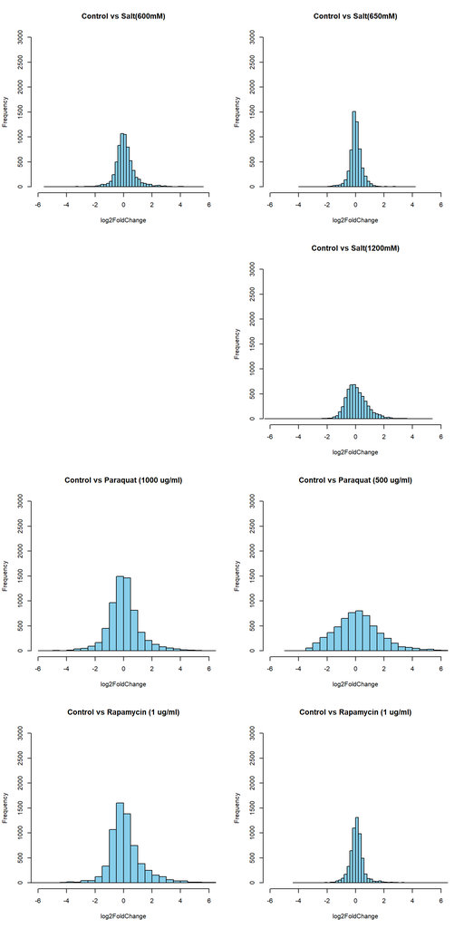

  Figure 7: Histogram, Single compound effect size

#### MA-PLOT

A scatter plot of log2 fold changes (on the y-axis) versus the mean of normalized counts (on the x-axis)

- **STEP1**:Data Preparation

Shrinkage of effect size (LFC estimates) is useful for visualization and ranking of genes. To shrink the LFC, we pass the dds object to the function lfcShrink. Below we specify to use the apeglm method for effect size shrinkage [Zhu, Ibrahim, and Love 2018](https://doi.org/10.1093/bioinformatics/bty895), which improves on the previous estimator.

We provide the dds object and the name or number of the coefficient we want to shrink, where the number refers to the order of the coefficient as it appears after using the **resultsNames()** function

```r
#
resultsNames(dds_T_SC)
```

```
## [1] "Intercept"              "condition_Para_vs_Ctrl" "condition_Rapa_vs_Ctrl"
## [4] "condition_Salt_vs_Ctrl" "condition_SaPa_vs_Ctrl" "condition_SaRa_vs_Ctrl"
```

```r
resultsNames(dds_T_DH)
```

```
## [1] "Intercept"               "condition_Para_vs_Ctrl"
## [3] "condition_Rapa_vs_Ctrl"  "condition_Salt1_vs_Ctrl"
## [5] "condition_Salt2_vs_Ctrl" "condition_SaPa_vs_Ctrl"
## [7] "condition_SaRa_vs_Ctrl"
```

```r
#Data_preparation_SC
resLFC_SC_Salt <- lfcShrink(dds_T_SC, coef = "condition_Salt_vs_Ctrl")
resLFC_SC_Para <- lfcShrink(dds_T_SC, coef = "condition_Para_vs_Ctrl")
resLFC_SC_SaPa <- lfcShrink(dds_T_SC, coef = "condition_SaPa_vs_Ctrl")
resLFC_SC_Rapa <- lfcShrink(dds_T_SC, coef = "condition_Rapa_vs_Ctrl")
resLFC_SC_SaRa <- lfcShrink(dds_T_SC, coef = "condition_SaRa_vs_Ctrl")
#Data_preparation_DH
resLFC_DH_Salt1 <- lfcShrink(dds_T_DH, coef = "condition_Salt1_vs_Ctrl")
resLFC_DH_Salt2 <- lfcShrink(dds_T_DH, coef = "condition_Salt2_vs_Ctrl")
resLFC_DH_Para <- lfcShrink(dds_T_DH, coef = "condition_Para_vs_Ctrl")
resLFC_DH_SaPa <- lfcShrink(dds_T_DH, coef = "condition_SaPa_vs_Ctrl")
resLFC_DH_Rapa <- lfcShrink(dds_T_DH, coef = "condition_Rapa_vs_Ctrl")
resLFC_DH_SaRa <- lfcShrink(dds_T_DH, coef = "condition_SaRa_vs_Ctrl")
```

- **STEP2**: PLOT the MA-plot

A. UNSHRUNKEN

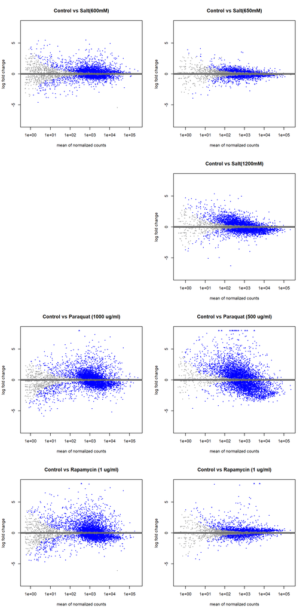

Figure 8: plotMA unshrunken, Single compound effect size

B. SHRUNKEN USING APEGLM

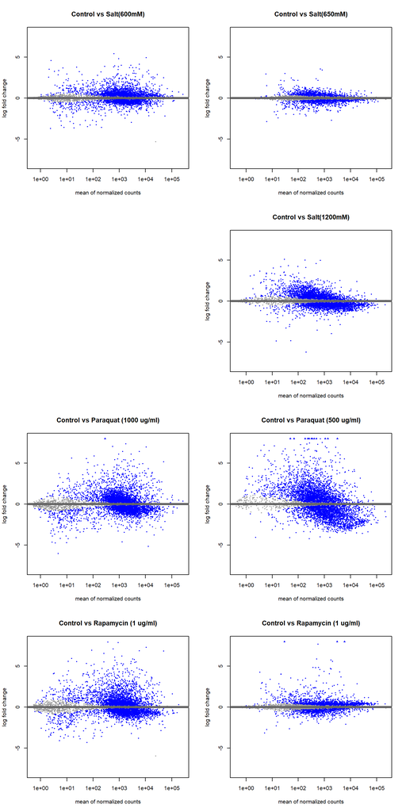

Figure 9: plotMA shrunken, Single compound effect size

#### VOLCANO PLOT

A. S. CEREVISIAE SINGLE COMPOUND

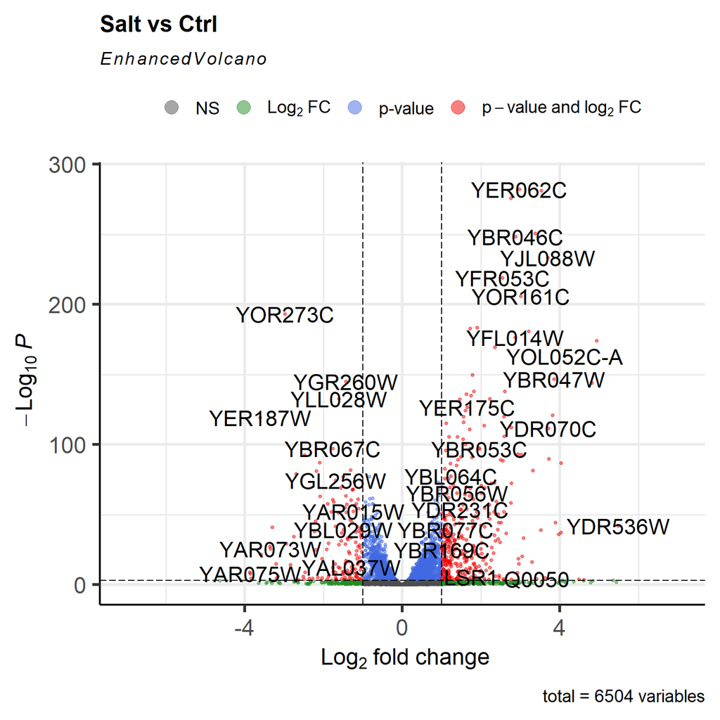

Figure 10: Volcano plot- SALT vs CTRL, S. cerevisiae, Single compound effect size

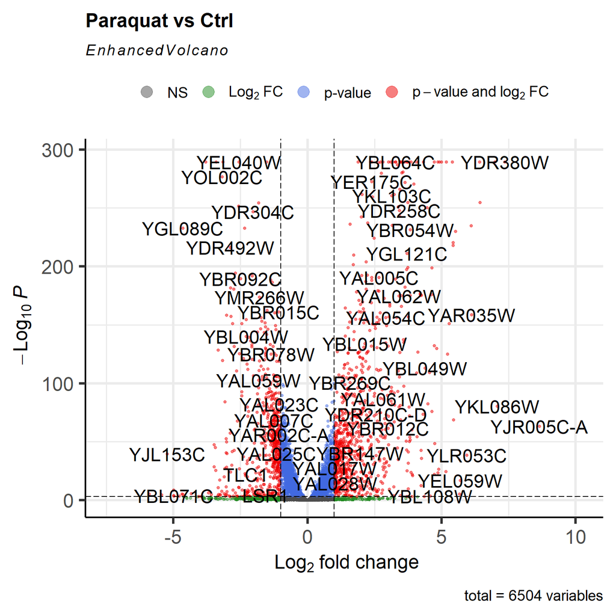

Figure 11: Volcano plot- PARA vs CTRL, S. cerevisiae, Single compound effect size

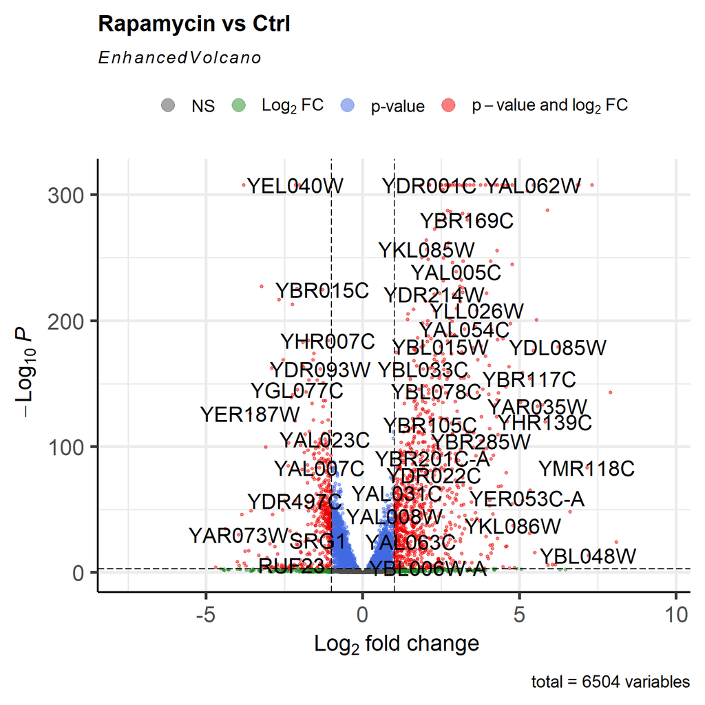

Figure 12: Volcano plot- RAPA vs CTRL, S. cerevisiae, Single compound effect size

## GROWTH RATE RELATED GENES EXPRESSION ANALYSIS

Import growth-related expression data from [brauer et al., 2008](https://doi.org/10.1091/mbc.e07-08-0779) file named **table_s1_Brauer_2008.tab** in the **COMPILED_DATA** folder

```r
Gene_ex_data <- read.csv(file = "COMPILED_DATA/table_s1_Brauer_2008.txt",
                                  header = TRUE,
                                  stringsAsFactors = FALSE,
                                  sep = "\t", na.strings = "")

Gene_names_ex_down <- Gene_ex_data$ORF[which(Gene_ex_data$Growth.Rate.Response..1.5SD=="down")]
Gene_names_ex_up <- Gene_ex_data$ORF[which(Gene_ex_data$Growth.Rate.Response..1.5SD=="up")]
```

### BOXPLOTS GROWTH RELATED GENES S. CEREVISIAE

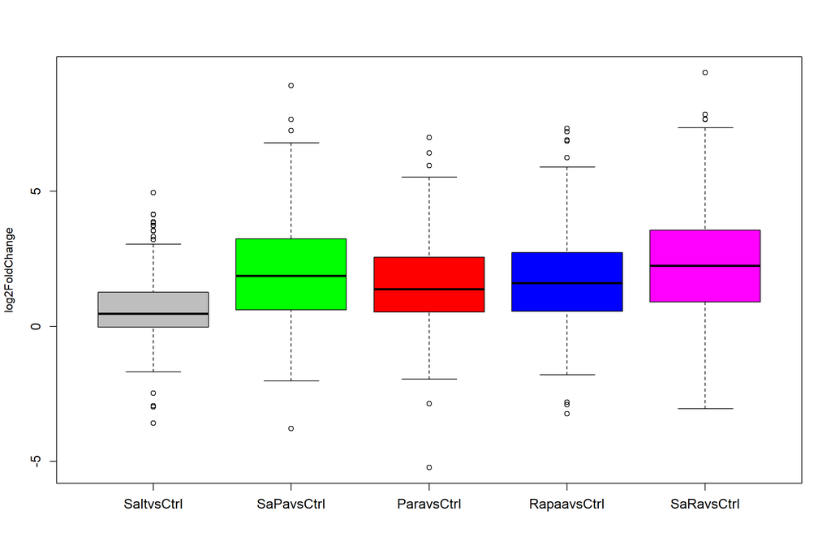

Figure 13: Growth related genes, boxplot log2fold change, S. cerevisiae, Gene set that downregulate with higher growh rate

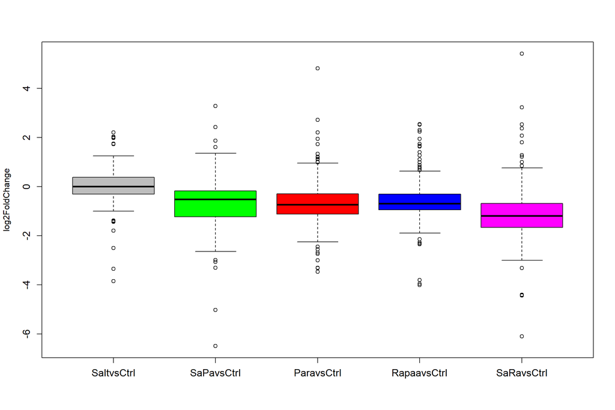

Figure 14: Growth related genes, boxplot log2fold change, S. cerevisiae, Gene set that upregulate with higher growh rate

### BOXPLOTS GROWTH RELATED GENES D. HANSENII

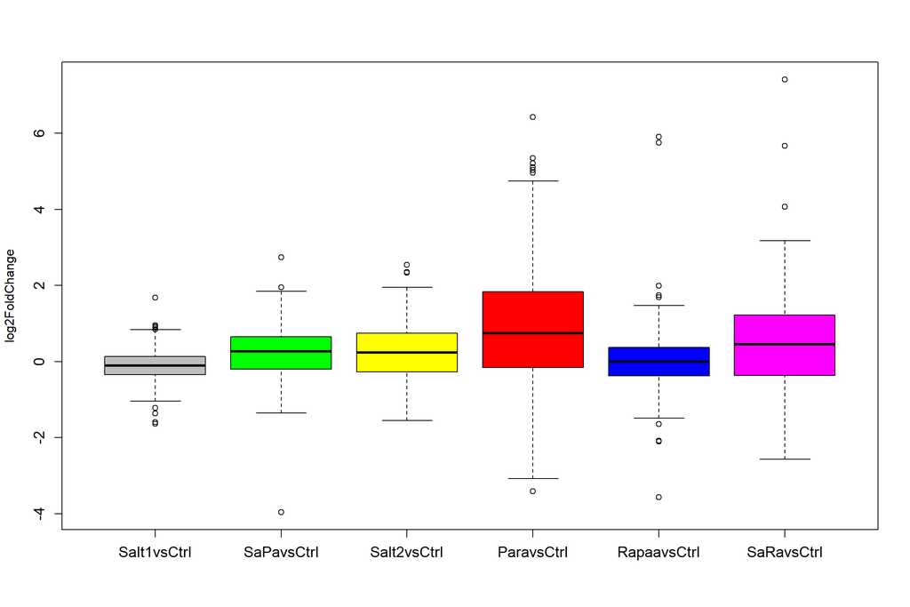

Figure 15: Growth related genes, boxplot log2fold change, D. hansenii orthologoues, Gene set that downregulate with higher growh rate

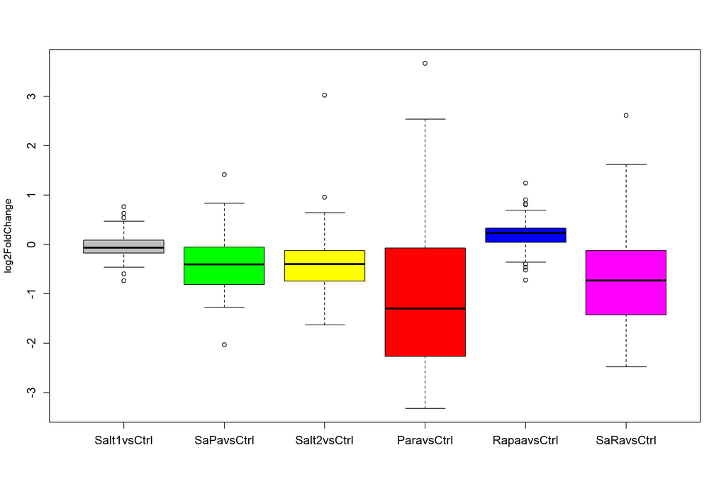

Figure 16: Growth related genes, boxplot log2fold change, D. hansenii orthologoues, Gene set that upregulate with higher growh rate

## THE GROWTH RATE VS EXPRESSION OF GROWTH RELATED GENES

### IMPORT PHENOMICS DATA

```r
#Importing the S. cerevisiae phenomics data
Phenodata_sc <- read.table("COMPILED_DATA/PHENOMICS_DATA/sc_whole_data.txt", header = TRUE, sep = "\t", as.is = TRUE)

#Importing the D. hansenii phenomics data
Phenodata_dh <- read.table("COMPILED_DATA/PHENOMICS_DATA/dh_whole_data.txt", header = TRUE, sep = "\t", as.is = TRUE)
```

### GROWTH RATE VS EXPRESSION SCATTER PLOT S. CEREVISIAE

```r
test_sc_p <- data.frame()

test_sc_p[1, 1] <- "salt_SC"
test_sc_p[1, 2] <- mean(Phenodata_sc$Growth.Rate[which(Phenodata_sc$ChemA == "Salt" &
                                                         Phenodata_sc$concA == 600 &
                                                         Phenodata_sc$concB == 0)])
test_sc_p[1, 3] <- sd(Phenodata_sc$Growth.Rate[which(Phenodata_sc$ChemA == "Salt" &
                                                         Phenodata_sc$concA == 600 &
                                                         Phenodata_sc$concB == 0)])
test_sc_p[1, 4] <- mean(na.omit(salt_SC_des$log2FoldChange[which(salt_SC_des$SYS_ID %in% Gene_names_ex_down)]))
test_sc_p[1, 5] <- sd(na.omit(salt_SC_des$log2FoldChange[which(salt_SC_des$SYS_ID %in% Gene_names_ex_down)]))
test_sc_p[1, 6] <- mean(na.omit(salt_SC_des$log2FoldChange[which(salt_SC_des$SYS_ID %in% Gene_names_ex_up)]))
test_sc_p[1, 7] <- sd(na.omit(salt_SC_des$log2FoldChange[which(salt_SC_des$SYS_ID %in% Gene_names_ex_up)]))


test_sc_p[2, 1] <- "para_SC"
test_sc_p[2, 2] <- mean(Phenodata_sc$Growth.Rate[which((Phenodata_sc$ChemA == "Paraquat" &
                                                         Phenodata_sc$concA == 1000 &
                                                         Phenodata_sc$concB == 0) |
                                                   (Phenodata_sc$ChemB == "Paraquat" &
                                                         Phenodata_sc$concA == 0 &
                                                         Phenodata_sc$concB == 1000)
                                                   )])
test_sc_p[2, 3] <- sd(Phenodata_sc$Growth.Rate[which((Phenodata_sc$ChemA == "Paraquat" &
                                                         Phenodata_sc$concA == 1000 &
                                                         Phenodata_sc$concB == 0) |
                                                   (Phenodata_sc$ChemB == "Paraquat" &
                                                         Phenodata_sc$concA == 0 &
                                                         Phenodata_sc$concB == 1000)
                                                   )])
test_sc_p[2, 4] <- mean(na.omit(para_SC_des$log2FoldChange[which(para_SC_des$SYS_ID %in% Gene_names_ex_down)]))
test_sc_p[2, 5] <- sd(na.omit(para_SC_des$log2FoldChange[which(para_SC_des$SYS_ID %in% Gene_names_ex_down)]))
test_sc_p[2, 6] <- mean(na.omit(para_SC_des$log2FoldChange[which(para_SC_des$SYS_ID %in% Gene_names_ex_up)]))
test_sc_p[2, 7] <- sd(na.omit(para_SC_des$log2FoldChange[which(para_SC_des$SYS_ID %in% Gene_names_ex_up)]))


test_sc_p[3, 1] <- "rapa_SC"
test_sc_p[3, 2] <- mean(Phenodata_sc$Growth.Rate[which((Phenodata_sc$ChemA == "Rapamycin" &
                                                         Phenodata_sc$concA == 1 &
                                                         Phenodata_sc$concB == 0) |
                                                   (Phenodata_sc$ChemB == "Rapamycin" &
                                                         Phenodata_sc$concA == 0 &
                                                         Phenodata_sc$concB == 1)
                                                   )])
test_sc_p[3, 3] <- sd(Phenodata_sc$Growth.Rate[which((Phenodata_sc$ChemA == "Rapamycin" &
                                                         Phenodata_sc$concA == 1 &
                                                         Phenodata_sc$concB == 0) |
                                                   (Phenodata_sc$ChemB == "Rapamycin" &
                                                         Phenodata_sc$concA == 0 &
                                                         Phenodata_sc$concB == 1)
                                                   )])
test_sc_p[3, 4] <- mean(na.omit(rapa_SC_des$log2FoldChange[which(rapa_SC_des$SYS_ID %in% Gene_names_ex_down)]))
test_sc_p[3, 5] <- sd(na.omit(rapa_SC_des$log2FoldChange[which(rapa_SC_des$SYS_ID %in% Gene_names_ex_down)]))
test_sc_p[3, 6] <- mean(na.omit(rapa_SC_des$log2FoldChange[which(rapa_SC_des$SYS_ID %in% Gene_names_ex_up)]))
test_sc_p[3, 7] <- sd(na.omit(rapa_SC_des$log2FoldChange[which(rapa_SC_des$SYS_ID %in% Gene_names_ex_up)]))

test_sc_p[4, 1] <- "SaPa_SC"
test_sc_p[4, 2] <- mean(Phenodata_sc$Growth.Rate[which((Phenodata_sc$ChemA == "Salt" &
                                                         Phenodata_sc$concA == 600 &
                                                          Phenodata_sc$ChemB == "Paraquat" &
                                                         Phenodata_sc$concB == 1000)
                                                   )])
test_sc_p[4, 3] <- sd(Phenodata_sc$Growth.Rate[which((Phenodata_sc$ChemA == "Salt" &
                                                         Phenodata_sc$concA == 600 &
                                                          Phenodata_sc$ChemB == "Paraquat" &
                                                         Phenodata_sc$concB == 1000)
                                                   )])
test_sc_p[4, 4] <- mean(na.omit(SaPa_SC_des$log2FoldChange[which(SaPa_SC_des$SYS_ID %in% Gene_names_ex_down)]))
test_sc_p[4, 5] <- sd(na.omit(SaPa_SC_des$log2FoldChange[which(SaPa_SC_des$SYS_ID %in% Gene_names_ex_down)]))
test_sc_p[4, 6] <- mean(na.omit(SaPa_SC_des$log2FoldChange[which(SaPa_SC_des$SYS_ID %in% Gene_names_ex_up)]))
test_sc_p[4, 7] <- sd(na.omit(SaPa_SC_des$log2FoldChange[which(SaPa_SC_des$SYS_ID %in% Gene_names_ex_up)]))

test_sc_p[5, 1] <- "SaRa_SC"
test_sc_p[5, 2] <- mean(Phenodata_sc$Growth.Rate[which((Phenodata_sc$ChemA == "Salt" &
                                                         Phenodata_sc$concA == 600 &
                                                          Phenodata_sc$ChemB == "Rapamycin" &
                                                         Phenodata_sc$concB == 1)
                                                   )])
test_sc_p[5, 3] <- sd(Phenodata_sc$Growth.Rate[which((Phenodata_sc$ChemA == "Salt" &
                                                         Phenodata_sc$concA == 600 &
                                                          Phenodata_sc$ChemB == "Rapamycin" &
                                                         Phenodata_sc$concB == 1)
                                                   )])
test_sc_p[5, 4] <- mean(na.omit(SaRa_SC_des$log2FoldChange[which(SaRa_SC_des$SYS_ID %in% Gene_names_ex_down)]))
test_sc_p[5, 5] <- sd(na.omit(SaRa_SC_des$log2FoldChange[which(SaRa_SC_des$SYS_ID %in% Gene_names_ex_down)]))
test_sc_p[5, 6] <- mean(na.omit(SaRa_SC_des$log2FoldChange[which(SaRa_SC_des$SYS_ID %in% Gene_names_ex_up)]))
test_sc_p[5, 7] <- sd(na.omit(SaRa_SC_des$log2FoldChange[which(SaRa_SC_des$SYS_ID %in% Gene_names_ex_up)]))

colnames(test_sc_p) <- c("Condition",
                         "GR_Mean",
                         "GR_SD",
                         "lfc_mean_down",
                         "lfc_SD_down",
                         "lfc_mean_up",
                         "lfc_SD_up")

test_sc_p <- test_sc_p[order(test_sc_p$GR_Mean), ]
```

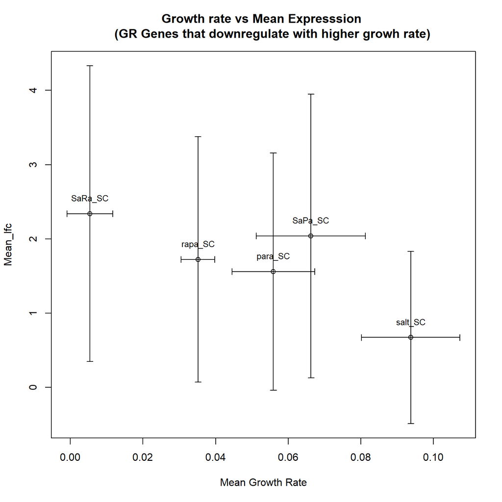

Figure 14: Growth rate vs Mean log2fold change, S. cerevisiae, with Gene set that downregulate with higher growh rate

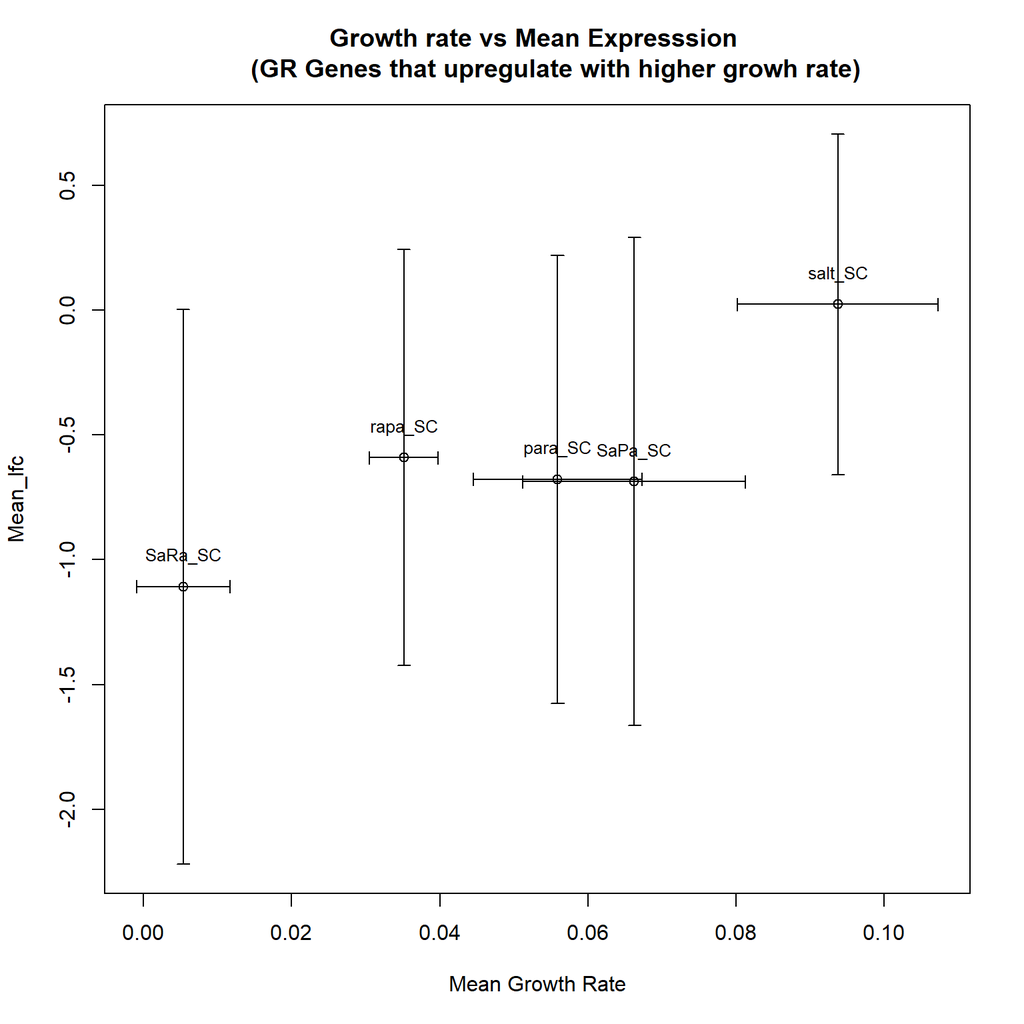

Figure 14: Growth rate vs Mean log2fold change, S. cerevisiae, with Gene set that upregulate with higher growh rate

## GO ENRICHMENT ANALYSIS

We performed GO enrichment analysis for both species for

- Single compound vs Control / Basal condition
- Mixture vs Single compound

### SINGLE COMPOUND / MIXTURE vs BASAL CONDITION

#### SALT (600mM) vs CTRL (SC)

```r
# WITH GROWTH RELATED GENES

GO_salt_SC_all <- salt_SC_des[which(abs(salt_SC_des$log2FoldChange) >= 1
                                              & salt_SC_des$padj <= 0.05), "SGD_DB_ID"]
GO_salt_SC_up <- salt_SC_des[which(salt_SC_des$log2FoldChange>= 1
                                              & salt_SC_des$padj <= 0.05), "SGD_DB_ID"]
GO_salt_SC_down <- salt_SC_des[which(salt_SC_des$log2FoldChange <= -1
                                              & salt_SC_des$padj <= 0.05), "SGD_DB_ID"]
# WITHOUT GROWTH RELATED GENES

#Extracting GROWTH RELATED GENES SGD ID

GRG_ALL_SGD_DB_ID <- salt_SC_des$SGD_DB_ID[which(salt_SC_des$SYS_ID %in% c(Gene_names_ex_up, Gene_names_ex_down))]

# Writing the Background set of SGD_ID i.e. all SGD_ID without Growth related gene IDs

BACKGROUND_GENESET_SGD_DB_ID <- salt_SC_des[which(!(salt_SC_des$SGD_DB_ID %in% GRG_ALL_SGD_DB_ID)), "SGD_DB_ID"]

# Extracting list for GO analysis

GO_salt_SC_all_wo_GRG <- salt_SC_des[which((abs(salt_SC_des$log2FoldChange) >= 1 & salt_SC_des$padj <= 0.05)
                                                     & !(salt_SC_des$SGD_DB_ID %in% GRG_ALL_SGD_DB_ID)), "SGD_DB_ID"]

GO_salt_SC_up_wo_GRG <- salt_SC_des[which((salt_SC_des$log2FoldChange >= 1 & salt_SC_des$padj <= 0.05)
                                                     & !(salt_SC_des$SGD_DB_ID %in% GRG_ALL_SGD_DB_ID)), "SGD_DB_ID"]

GO_salt_SC_down_wo_GRG <- salt_SC_des[which((salt_SC_des$log2FoldChange <= -1 & salt_SC_des$padj <= 0.05)
                                                     & !(salt_SC_des$SGD_DB_ID %in% GRG_ALL_SGD_DB_ID)), "SGD_DB_ID"]
#WRITE TABLE
#Eg. write.table(GO_salt_SC_all, file = "COMPILED_DATA/GO_GENE_LISTS_SC/GO_salt_SC_all.txt", sep = "\t", na = "NA", row.names = FALSE, col.names = FALSE, quote = FALSE)

#write.table(BACKGROUND_GENESET_SGD_DB_ID, file = "COMPILED_DATA/GO_GENE_LISTS_SC/BACKGROUND_GENESET_SGD_DB_ID.txt", sep = "\t", na = "NA", row.names = FALSE, col.names = FALSE, quote = FALSE)
```

#### SALT (650mM) vs CTRL (DH)

```r
# WITH GROWTH RELATED GENES

GO_salt1_DH_all <- salt1_DH_des[which(abs(salt1_DH_des$log2FoldChange) >= 1
                                              & salt1_DH_des$padj <= 0.05), "SGD_DB_ID"]
GO_salt1_DH_up <- salt1_DH_des[which(salt1_DH_des$log2FoldChange>= 1
                                              & salt1_DH_des$padj <= 0.05), "SGD_DB_ID"]
GO_salt1_DH_down <- salt1_DH_des[which(salt1_DH_des$log2FoldChange <= -1
                                              & salt1_DH_des$padj <= 0.05), "SGD_DB_ID"]

# WITHOUT GROWTH RELATED GENES

# Extracting list for GO analysis

GO_salt1_DH_all_wo_GRG <- salt1_DH_des[which((abs(salt1_DH_des$log2FoldChange) >= 1 & salt1_DH_des$padj <= 0.05)
                                                     & !(salt1_DH_des$SGD_DB_ID %in% GRG_ALL_SGD_DB_ID)), "SGD_DB_ID"]

GO_salt1_DH_up_wo_GRG <- salt1_DH_des[which((salt1_DH_des$log2FoldChange >= 1 & salt1_DH_des$padj <= 0.05)
                                                     & !(salt1_DH_des$SGD_DB_ID %in% GRG_ALL_SGD_DB_ID)), "SGD_DB_ID"]

GO_salt1_DH_down_wo_GRG <- salt1_DH_des[which((salt1_DH_des$log2FoldChange <= -1 & salt1_DH_des$padj <= 0.05)
                                                     & !(salt1_DH_des$SGD_DB_ID %in% GRG_ALL_SGD_DB_ID)), "SGD_DB_ID"]

#WRITE TABLE
#write.table(GO_salt1_DH_all_wo_GRG, file = "COMPILED_DATA/GO_GENE_LISTS_DH/GO_Input_wo_GRG/GO_salt1_DH_all_wo_GRG.txt", sep = "\t", na = "NA", row.names = FALSE, col.names = FALSE, quote = FALSE)
```

#### SALT (1200mM) vs CTRL (DH)

```r
# WITH GROWTH RELATED GENES

GO_salt2_DH_all <- salt2_DH_des[which(abs(salt2_DH_des$log2FoldChange) >= 1
                                              & salt2_DH_des$padj <= 0.05), "SGD_DB_ID"]
GO_salt2_DH_up <- salt2_DH_des[which(salt2_DH_des$log2FoldChange>= 1
                                              & salt2_DH_des$padj <= 0.05), "SGD_DB_ID"]
GO_salt2_DH_down <- salt2_DH_des[which(salt2_DH_des$log2FoldChange <= -1
                                              & salt2_DH_des$padj <= 0.05), "SGD_DB_ID"]

# WITHOUT GROWTH RELATED GENES

# Extracting list for GO analysis

GO_salt2_DH_all_wo_GRG <- salt2_DH_des[which((abs(salt2_DH_des$log2FoldChange) >= 1 & salt2_DH_des$padj <= 0.05)
                                                     & !(salt2_DH_des$SGD_DB_ID %in% GRG_ALL_SGD_DB_ID)), "SGD_DB_ID"]

GO_salt2_DH_up_wo_GRG <- salt2_DH_des[which((salt2_DH_des$log2FoldChange >= 1 & salt2_DH_des$padj <= 0.05)
                                                     & !(salt2_DH_des$SGD_DB_ID %in% GRG_ALL_SGD_DB_ID)), "SGD_DB_ID"]

GO_salt2_DH_down_wo_GRG <- salt2_DH_des[which((salt2_DH_des$log2FoldChange <= -1 & salt2_DH_des$padj <= 0.05)
                                                     & !(salt2_DH_des$SGD_DB_ID %in% GRG_ALL_SGD_DB_ID)), "SGD_DB_ID"]

#WRITE TABLE
#write.table(GO_salt2_DH_down, file = "COMPILED_DATA/GO_GENE_LISTS_DH/GO_Input/GO_salt2_DH_down.txt", sep = "\t", na = "NA", row.names = FALSE, col.names = FALSE, quote = FALSE)
```

#### PARA (1000 ug/ml) vs CTRL (SC)

```r
# WITH GROWTH RELATED GENES

GO_para_SC_all <- para_SC_des[which(abs(para_SC_des$log2FoldChange) >= 1
                                              & para_SC_des$padj <= 0.05), "SGD_DB_ID"]
GO_para_SC_up <- para_SC_des[which(para_SC_des$log2FoldChange>= 1
                                              & para_SC_des$padj <= 0.05), "SGD_DB_ID"]
GO_para_SC_down <- para_SC_des[which(para_SC_des$log2FoldChange <= -1
                                              & para_SC_des$padj <= 0.05), "SGD_DB_ID"]
# WITHOUT GROWTH RELATED GENES

GO_para_SC_all_wo_GRG <- para_SC_des[which((abs(para_SC_des$log2FoldChange) >= 1 & para_SC_des$padj <= 0.05)
                                                     & !(para_SC_des$SGD_DB_ID %in% GRG_ALL_SGD_DB_ID)), "SGD_DB_ID"]

GO_para_SC_up_wo_GRG <- para_SC_des[which((para_SC_des$log2FoldChange >= 1 & para_SC_des$padj <= 0.05)
                                                     & !(para_SC_des$SGD_DB_ID %in% GRG_ALL_SGD_DB_ID)), "SGD_DB_ID"]

GO_para_SC_down_wo_GRG <- para_SC_des[which((para_SC_des$log2FoldChange <= -1 & para_SC_des$padj <= 0.05)
                                                     & !(para_SC_des$SGD_DB_ID %in% GRG_ALL_SGD_DB_ID)), "SGD_DB_ID"]
#WRITE TABLE
#Eg. write.table(GO_para_SC_all, file = "COMPILED_DATA/GO_GENE_LISTS_SC/GO_para_SC_all.txt", sep = "\t", na = "NA", row.names = FALSE, col.names = FALSE, quote = FALSE)
```

#### PARA (500 ug/ml) vs CTRL (DH)

```r
# WITH GROWTH RELATED GENES

GO_para_DH_all <- para_DH_des[which(abs(para_DH_des$log2FoldChange) >= 1
                                              & para_DH_des$padj <= 0.05), "SGD_DB_ID"]
GO_para_DH_up <- para_DH_des[which(para_DH_des$log2FoldChange>= 1
                                              & para_DH_des$padj <= 0.05), "SGD_DB_ID"]
GO_para_DH_down <- para_DH_des[which(para_DH_des$log2FoldChange <= -1
                                              & para_DH_des$padj <= 0.05), "SGD_DB_ID"]
# WITHOUT GROWTH RELATED GENES

GO_para_DH_all_wo_GRG <- para_DH_des[which((abs(para_DH_des$log2FoldChange) >= 1 & para_DH_des$padj <= 0.05)
                                                     & !(para_DH_des$SGD_DB_ID %in% GRG_ALL_SGD_DB_ID)), "SGD_DB_ID"]

GO_para_DH_up_wo_GRG <- para_DH_des[which((para_DH_des$log2FoldChange >= 1 & para_DH_des$padj <= 0.05)
                                                     & !(para_DH_des$SGD_DB_ID %in% GRG_ALL_SGD_DB_ID)), "SGD_DB_ID"]

GO_para_DH_down_wo_GRG <- para_DH_des[which((para_DH_des$log2FoldChange <= -1 & para_DH_des$padj <= 0.05)
                                                     & !(para_DH_des$SGD_DB_ID %in% GRG_ALL_SGD_DB_ID)), "SGD_DB_ID"]
#WRITE TABLE
#write.table(GO_para_DH_up, file = "COMPILED_DATA/GO_GENE_LISTS_DH/GO_Input/GO_para_DH_up.txt", sep = "\t", na = "NA", row.names = FALSE, col.names = FALSE, quote = FALSE)
```

#### RAPA (1 ug/ml) vs CTRL (SC)

```r
# WITH GROWTH RELATED GENES

GO_rapa_SC_all <- rapa_SC_des[which(abs(rapa_SC_des$log2FoldChange) >= 1
                                              & rapa_SC_des$padj <= 0.05), "SGD_DB_ID"]
GO_rapa_SC_up <- rapa_SC_des[which(rapa_SC_des$log2FoldChange>= 1
                                              & rapa_SC_des$padj <= 0.05), "SGD_DB_ID"]
GO_rapa_SC_down <- rapa_SC_des[which(rapa_SC_des$log2FoldChange <= -1
                                              & rapa_SC_des$padj <= 0.05), "SGD_DB_ID"]
# WITHOUT GROWTH RELATED GENES

GO_rapa_SC_all_wo_GRG <- rapa_SC_des[which((abs(rapa_SC_des$log2FoldChange) >= 1 & rapa_SC_des$padj <= 0.05)
                                                     & !(rapa_SC_des$SGD_DB_ID %in% GRG_ALL_SGD_DB_ID)), "SGD_DB_ID"]

GO_rapa_SC_up_wo_GRG <- rapa_SC_des[which((rapa_SC_des$log2FoldChange >= 1 & rapa_SC_des$padj <= 0.05)
                                                     & !(rapa_SC_des$SGD_DB_ID %in% GRG_ALL_SGD_DB_ID)), "SGD_DB_ID"]

GO_rapa_SC_down_wo_GRG <- rapa_SC_des[which((rapa_SC_des$log2FoldChange <= -1 & rapa_SC_des$padj <= 0.05)
                                                     & !(rapa_SC_des$SGD_DB_ID %in% GRG_ALL_SGD_DB_ID)), "SGD_DB_ID"]
#WRITE TABLE
#Eg. write.table(GO_rapa_SC_all, file = "COMPILED_DATA/GO_GENE_LISTS_SC/GO_rapa_SC_all.txt", sep = "\t", na = "NA", row.names = FALSE, col.names = FALSE, quote = FALSE)
```

#### RAPA (1 ug/ml) vs CTRL (DH)

```r
# WITH GROWTH RELATED GENES
GO_rapa_DH_all <- rapa_DH_des[which(abs(rapa_DH_des$log2FoldChange) >= 1
                                              & rapa_DH_des$padj <= 0.05), "SGD_DB_ID"]
GO_rapa_DH_up <- rapa_DH_des[which(rapa_DH_des$log2FoldChange>= 1
                                              & rapa_DH_des$padj <= 0.05), "SGD_DB_ID"]
GO_rapa_DH_down <- rapa_DH_des[which(rapa_DH_des$log2FoldChange <= -1
                                              & rapa_DH_des$padj <= 0.05), "SGD_DB_ID"]
# WITHOUT GROWTH RELATED GENES

GO_rapa_DH_all_wo_GRG <- rapa_DH_des[which((abs(rapa_DH_des$log2FoldChange) >= 1 & rapa_DH_des$padj <= 0.05)
                                                     & !(rapa_DH_des$SGD_DB_ID %in% GRG_ALL_SGD_DB_ID)), "SGD_DB_ID"]

GO_rapa_DH_up_wo_GRG <- rapa_DH_des[which((rapa_DH_des$log2FoldChange >= 1 & rapa_DH_des$padj <= 0.05)
                                                     & !(rapa_DH_des$SGD_DB_ID %in% GRG_ALL_SGD_DB_ID)), "SGD_DB_ID"]

GO_rapa_DH_down_wo_GRG <- rapa_DH_des[which((rapa_DH_des$log2FoldChange <= -1 & rapa_DH_des$padj <= 0.05)
                                                     & !(rapa_DH_des$SGD_DB_ID %in% GRG_ALL_SGD_DB_ID)), "SGD_DB_ID"]
#WRITE TABLE
#write.table(GO_rapa_DH_down_wo_GRG, file = "COMPILED_DATA/GO_GENE_LISTS_DH/GO_Input_wo_GRG/GO_rapa_DH_down_wo_GRG.txt", sep = "\t", na = "NA", row.names = FALSE, col.names = FALSE, quote = FALSE)
```

#### SAPA (600 mM salt and 1000 ug/ml paraquat) vs CTRL (SC)

```r
# WITH GROWTH RELATED GENES

GO_SaPa_SC_all <- SaPa_SC_des[which(abs(SaPa_SC_des$log2FoldChange) >= 1
                                              & SaPa_SC_des$padj <= 0.05), "SGD_DB_ID"]
GO_SaPa_SC_up <- SaPa_SC_des[which(SaPa_SC_des$log2FoldChange>= 1
                                              & SaPa_SC_des$padj <= 0.05), "SGD_DB_ID"]
GO_SaPa_SC_down <- SaPa_SC_des[which(SaPa_SC_des$log2FoldChange <= -1
                                              & SaPa_SC_des$padj <= 0.05), "SGD_DB_ID"]
# WITHOUT GROWTH RELATED GENES

GO_SaPa_SC_all_wo_GRG <- SaPa_SC_des[which((abs(SaPa_SC_des$log2FoldChange) >= 1 & SaPa_SC_des$padj <= 0.05)
                                                     & !(SaPa_SC_des$SGD_DB_ID %in% GRG_ALL_SGD_DB_ID)), "SGD_DB_ID"]

GO_SaPa_SC_up_wo_GRG <- SaPa_SC_des[which((SaPa_SC_des$log2FoldChange >= 1 & SaPa_SC_des$padj <= 0.05)
                                                     & !(SaPa_SC_des$SGD_DB_ID %in% GRG_ALL_SGD_DB_ID)), "SGD_DB_ID"]

GO_SaPa_SC_down_wo_GRG <- SaPa_SC_des[which((SaPa_SC_des$log2FoldChange <= -1 & SaPa_SC_des$padj <= 0.05)
                                                     & !(SaPa_SC_des$SGD_DB_ID %in% GRG_ALL_SGD_DB_ID)), "SGD_DB_ID"]
#WRITE TABLE
#Eg. write.table(GO_SaPa_SC_all, file = "COMPILED_DATA/GO_GENE_LISTS_SC/GO_SaPa_SC_all.txt", sep = "\t", na = "NA", row.names = FALSE, col.names = FALSE, quote = FALSE)
```

#### SAPA (650 mM salt and 500 ug/ml paraquat) vs CTRL (DH)

```r
# WITH GROWTH RELATED GENES

GO_SaPa_DH_all <- SaPa_DH_des[which(abs(SaPa_DH_des$log2FoldChange) >= 1
                                              & SaPa_DH_des$padj <= 0.05), "SGD_DB_ID"]
GO_SaPa_DH_up <- SaPa_DH_des[which(SaPa_DH_des$log2FoldChange>= 1
                                              & SaPa_DH_des$padj <= 0.05), "SGD_DB_ID"]
GO_SaPa_DH_down <- SaPa_DH_des[which(SaPa_DH_des$log2FoldChange <= -1
                                              & SaPa_DH_des$padj <= 0.05), "SGD_DB_ID"]
# WITHOUT GROWTH RELATED GENES

GO_SaPa_DH_all_wo_GRG <- SaPa_DH_des[which((abs(SaPa_DH_des$log2FoldChange) >= 1 & SaPa_DH_des$padj <= 0.05)
                                                     & !(SaPa_DH_des$SGD_DB_ID %in% GRG_ALL_SGD_DB_ID)), "SGD_DB_ID"]

GO_SaPa_DH_up_wo_GRG <- SaPa_DH_des[which((SaPa_DH_des$log2FoldChange >= 1 & SaPa_DH_des$padj <= 0.05)
                                                     & !(SaPa_DH_des$SGD_DB_ID %in% GRG_ALL_SGD_DB_ID)), "SGD_DB_ID"]

GO_SaPa_DH_down_wo_GRG <- SaPa_DH_des[which((SaPa_DH_des$log2FoldChange <= -1 & SaPa_DH_des$padj <= 0.05)
                                                     & !(SaPa_DH_des$SGD_DB_ID %in% GRG_ALL_SGD_DB_ID)), "SGD_DB_ID"]
#WRITE TABLE
#write.table(GO_SaPa_DH_down, file = "COMPILED_DATA/GO_GENE_LISTS_DH/GO_Input/GO_SaPa_DH_down.txt", sep = "\t", na = "NA", row.names = FALSE, col.names = FALSE, quote = FALSE)
```

#### SARA (600 mM salt and 1 ug/ml rapamycin) vs CTRL (SC)

```r
# WITH GROWTH RELATED GENES

GO_SaRa_SC_all <- SaRa_SC_des[which(abs(SaRa_SC_des$log2FoldChange) >= 1
                                              & SaRa_SC_des$padj <= 0.05), "SGD_DB_ID"]
GO_SaRa_SC_up <- SaRa_SC_des[which(SaRa_SC_des$log2FoldChange>= 1
                                              & SaRa_SC_des$padj <= 0.05), "SGD_DB_ID"]
GO_SaRa_SC_down <- SaRa_SC_des[which(SaRa_SC_des$log2FoldChange <= -1
                                              & SaRa_SC_des$padj <= 0.05), "SGD_DB_ID"]
# WITHOUT GROWTH RELATED GENES

GO_SaRa_SC_all_wo_GRG <- SaRa_SC_des[which((abs(SaRa_SC_des$log2FoldChange) >= 1 & SaRa_SC_des$padj <= 0.05)
                                                     & !(SaRa_SC_des$SGD_DB_ID %in% GRG_ALL_SGD_DB_ID)), "SGD_DB_ID"]

GO_SaRa_SC_up_wo_GRG <- SaRa_SC_des[which((SaRa_SC_des$log2FoldChange >= 1 & SaRa_SC_des$padj <= 0.05)
                                                     & !(SaRa_SC_des$SGD_DB_ID %in% GRG_ALL_SGD_DB_ID)), "SGD_DB_ID"]

GO_SaRa_SC_down_wo_GRG <- SaRa_SC_des[which((SaRa_SC_des$log2FoldChange <= -1 & SaRa_SC_des$padj <= 0.05)
                                                     & !(SaRa_SC_des$SGD_DB_ID %in% GRG_ALL_SGD_DB_ID)), "SGD_DB_ID"]
#WRITE TABLE
#Eg. write.table(GO_SaRa_SC_all, file = "COMPILED_DATA/GO_GENE_LISTS_SC/GO_SaRa_SC_all.txt", sep = "\t", na = "NA", row.names = FALSE, col.names = FALSE, quote = FALSE)
```

#### SARA (1200 mM salt and 1 ug/ml rapamycin) vs CTRL (DH)

```r
# WITH GROWTH RELATED GENES

GO_SaRa_DH_all <- SaRa_DH_des[which(abs(SaRa_DH_des$log2FoldChange) >= 1
                                              & SaRa_DH_des$padj <= 0.05), "SGD_DB_ID"]
GO_SaRa_DH_up <- SaRa_DH_des[which(SaRa_DH_des$log2FoldChange>= 1
                                              & SaRa_DH_des$padj <= 0.05), "SGD_DB_ID"]
GO_SaRa_DH_down <- SaRa_DH_des[which(SaRa_DH_des$log2FoldChange <= -1
                                              & SaRa_DH_des$padj <= 0.05), "SGD_DB_ID"]
# WITHOUT GROWTH RELATED GENES

GO_SaRa_DH_all_wo_GRG <- SaRa_DH_des[which((abs(SaRa_DH_des$log2FoldChange) >= 1 & SaRa_DH_des$padj <= 0.05)
                                                     & !(SaRa_DH_des$SGD_DB_ID %in% GRG_ALL_SGD_DB_ID)), "SGD_DB_ID"]

GO_SaRa_DH_up_wo_GRG <- SaRa_DH_des[which((SaRa_DH_des$log2FoldChange >= 1 & SaRa_DH_des$padj <= 0.05)
                                                     & !(SaRa_DH_des$SGD_DB_ID %in% GRG_ALL_SGD_DB_ID)), "SGD_DB_ID"]

GO_SaRa_DH_down_wo_GRG <- SaRa_DH_des[which((SaRa_DH_des$log2FoldChange <= -1 & SaRa_DH_des$padj <= 0.05)
                                                     & !(SaRa_DH_des$SGD_DB_ID %in% GRG_ALL_SGD_DB_ID)), "SGD_DB_ID"]
#WRITE TABLE
write.table(GO_SaRa_DH_all_wo_GRG, file = "COMPILED_DATA/GO_GENE_LISTS_DH/GO_Input_wo_GRG/GO_SaRa_DH_all_wo_GRG.txt", sep = "\t", na = "NA", row.names = FALSE, col.names = FALSE, quote = FALSE)
```

### MIXTURE vs SINGLE COMPOUND

#### SAPA (600 mM salt and 1000 ug/ml paraquat) vs SALT (600 mM) (SC)

```r
# WITH GROWTH RELATED GENES

GO_SaPavsSalt_SC_all <- SaPavsSalt_SC_des[which(abs(SaPavsSalt_SC_des$log2FoldChange) >= 1
                                              & SaPavsSalt_SC_des$padj <= 0.05), "SGD_DB_ID"]
GO_SaPavsSalt_SC_up <- SaPavsSalt_SC_des[which(SaPavsSalt_SC_des$log2FoldChange>= 1
                                              & SaPavsSalt_SC_des$padj <= 0.05), "SGD_DB_ID"]
GO_SaPavsSalt_SC_down <- SaPavsSalt_SC_des[which(SaPavsSalt_SC_des$log2FoldChange <= -1
                                              & SaPavsSalt_SC_des$padj <= 0.05), "SGD_DB_ID"]
# WITHOUT GROWTH RELATED GENES

GO_SaPavsSalt_SC_all_wo_GRG <- SaPavsSalt_SC_des[which((abs(SaPavsSalt_SC_des$log2FoldChange) >= 1 & SaPavsSalt_SC_des$padj <= 0.05)
                                                     & !(SaPavsSalt_SC_des$SGD_DB_ID %in% GRG_ALL_SGD_DB_ID)), "SGD_DB_ID"]

GO_SaPavsSalt_SC_up_wo_GRG <- SaPavsSalt_SC_des[which((SaPavsSalt_SC_des$log2FoldChange >= 1 & SaPavsSalt_SC_des$padj <= 0.05)
                                                     & !(SaPavsSalt_SC_des$SGD_DB_ID %in% GRG_ALL_SGD_DB_ID)), "SGD_DB_ID"]

GO_SaPavsSalt_SC_down_wo_GRG <- SaPavsSalt_SC_des[which((SaPavsSalt_SC_des$log2FoldChange <= -1 & SaPavsSalt_SC_des$padj <= 0.05)
                                                     & !(SaPavsSalt_SC_des$SGD_DB_ID %in% GRG_ALL_SGD_DB_ID)), "SGD_DB_ID"]
#WRITE TABLE
#Eg. write.table(GO_SaPavsSalt_SC_all, file = "COMPILED_DATA/GO_GENE_LISTS_SC/GO_SaPavsSalt_SC_all.txt", sep = "\t", na = "NA", row.names = FALSE, col.names = FALSE, quote = FALSE)
```

#### SAPA (650 mM salt and 500 ug/ml paraquat) vs SALT (650 mM) (DH)

```r
# WITH GROWTH RELATED GENES

GO_SaPavsSalt1_DH_all <- SaPavsSalt1_DH_des[which(abs(SaPavsSalt1_DH_des$log2FoldChange) >= 1
                                              & SaPavsSalt1_DH_des$padj <= 0.05), "SGD_DB_ID"]
GO_SaPavsSalt1_DH_up <- SaPavsSalt1_DH_des[which(SaPavsSalt1_DH_des$log2FoldChange>= 1
                                              & SaPavsSalt1_DH_des$padj <= 0.05), "SGD_DB_ID"]
GO_SaPavsSalt1_DH_down <- SaPavsSalt1_DH_des[which(SaPavsSalt1_DH_des$log2FoldChange <= -1
                                              & SaPavsSalt1_DH_des$padj <= 0.05), "SGD_DB_ID"]
# WITHOUT GROWTH RELATED GENES

GO_SaPavsSalt1_DH_all_wo_GRG <- SaPavsSalt1_DH_des[which((abs(SaPavsSalt1_DH_des$log2FoldChange) >= 1 & SaPavsSalt1_DH_des$padj <= 0.05)
                                                     & !(SaPavsSalt1_DH_des$SGD_DB_ID %in% GRG_ALL_SGD_DB_ID)), "SGD_DB_ID"]

GO_SaPavsSalt1_DH_up_wo_GRG <- SaPavsSalt1_DH_des[which((SaPavsSalt1_DH_des$log2FoldChange >= 1 & SaPavsSalt1_DH_des$padj <= 0.05)
                                                     & !(SaPavsSalt1_DH_des$SGD_DB_ID %in% GRG_ALL_SGD_DB_ID)), "SGD_DB_ID"]

GO_SaPavsSalt1_DH_down_wo_GRG <- SaPavsSalt1_DH_des[which((SaPavsSalt1_DH_des$log2FoldChange <= -1 & SaPavsSalt1_DH_des$padj <= 0.05)
                                                     & !(SaPavsSalt1_DH_des$SGD_DB_ID %in% GRG_ALL_SGD_DB_ID)), "SGD_DB_ID"]
#WRITE TABLE
#write.table(GO_SaPavsSalt1_DH_all_wo_GRG, file = "COMPILED_DATA/GO_GENE_LISTS_DH/GO_Input_wo_GRG/GO_SaPavsSalt1_DH_all_wo_GRG.txt", sep = "\t", na = "NA", row.names = FALSE, col.names = FALSE, quote = FALSE)
```

#### SAPA (600 mM salt and 1000 ug/ml paraquat) vs PARA (1000 ug/ml paraquat) (SC)

```r
# WITH GROWTH RELATED GENES

GO_SaPavsPara_SC_all <- SaPavsPara_SC_des[which(abs(SaPavsPara_SC_des$log2FoldChange) >= 1
                                              & SaPavsPara_SC_des$padj <= 0.05), "SGD_DB_ID"]
GO_SaPavsPara_SC_up <- SaPavsPara_SC_des[which(SaPavsPara_SC_des$log2FoldChange>= 1
                                              & SaPavsPara_SC_des$padj <= 0.05), "SGD_DB_ID"]
GO_SaPavsPara_SC_down <- SaPavsPara_SC_des[which(SaPavsPara_SC_des$log2FoldChange <= -1
                                              & SaPavsPara_SC_des$padj <= 0.05), "SGD_DB_ID"]
# WITHOUT GROWTH RELATED GENES

GO_SaPavsPara_SC_all_wo_GRG <- SaPavsPara_SC_des[which((abs(SaPavsPara_SC_des$log2FoldChange) >= 1 & SaPavsPara_SC_des$padj <= 0.05)
                                                     & !(SaPavsPara_SC_des$SGD_DB_ID %in% GRG_ALL_SGD_DB_ID)), "SGD_DB_ID"]

GO_SaPavsPara_SC_up_wo_GRG <- SaPavsPara_SC_des[which((SaPavsPara_SC_des$log2FoldChange >= 1 & SaPavsPara_SC_des$padj <= 0.05)
                                                     & !(SaPavsPara_SC_des$SGD_DB_ID %in% GRG_ALL_SGD_DB_ID)), "SGD_DB_ID"]

GO_SaPavsPara_SC_down_wo_GRG <- SaPavsPara_SC_des[which((SaPavsPara_SC_des$log2FoldChange <= -1 & SaPavsPara_SC_des$padj <= 0.05)
                                                     & !(SaPavsPara_SC_des$SGD_DB_ID %in% GRG_ALL_SGD_DB_ID)), "SGD_DB_ID"]
#WRITE TABLE
#Eg. write.table(GO_SaPavsPara_SC_all, file = "COMPILED_DATA/GO_GENE_LISTS_SC/GO_SaPavsPara_SC_all.txt", sep = "\t", na = "NA", row.names = FALSE, col.names = FALSE, quote = FALSE)
```

#### SAPA (650 mM salt and 500 ug/ml paraquat) vs PARA (500 ug/ml paraquat) (DH)

```r
# WITH GROWTH RELATED GENES

GO_SaPavsPara_DH_all <- SaPavsPara_DH_des[which(abs(SaPavsPara_DH_des$log2FoldChange) >= 1
                                              & SaPavsPara_DH_des$padj <= 0.05), "SGD_DB_ID"]
GO_SaPavsPara_DH_up <- SaPavsPara_DH_des[which(SaPavsPara_DH_des$log2FoldChange>= 1
                                              & SaPavsPara_DH_des$padj <= 0.05), "SGD_DB_ID"]
GO_SaPavsPara_DH_down <- SaPavsPara_DH_des[which(SaPavsPara_DH_des$log2FoldChange <= -1
                                              & SaPavsPara_DH_des$padj <= 0.05), "SGD_DB_ID"]
# WITHOUT GROWTH RELATED GENES

GO_SaPavsPara_DH_all_wo_GRG <- SaPavsPara_DH_des[which((abs(SaPavsPara_DH_des$log2FoldChange) >= 1 & SaPavsPara_DH_des$padj <= 0.05)
                                                     & !(SaPavsPara_DH_des$SGD_DB_ID %in% GRG_ALL_SGD_DB_ID)), "SGD_DB_ID"]

GO_SaPavsPara_DH_up_wo_GRG <- SaPavsPara_DH_des[which((SaPavsPara_DH_des$log2FoldChange >= 1 & SaPavsPara_DH_des$padj <= 0.05)
                                                     & !(SaPavsPara_DH_des$SGD_DB_ID %in% GRG_ALL_SGD_DB_ID)), "SGD_DB_ID"]

GO_SaPavsPara_DH_down_wo_GRG <- SaPavsPara_DH_des[which((SaPavsPara_DH_des$log2FoldChange <= -1 & SaPavsPara_DH_des$padj <= 0.05)
                                                     & !(SaPavsPara_DH_des$SGD_DB_ID %in% GRG_ALL_SGD_DB_ID)), "SGD_DB_ID"]
#WRITE TABLE
#write.table(GO_SaPavsPara_DH_all_wo_GRG, file = "COMPILED_DATA/GO_GENE_LISTS_DH/GO_Input_wo_GRG/GO_SaPavsPara_DH_all_wo_GRG.txt", sep = "\t", na = "NA", row.names = FALSE, col.names = FALSE, quote = FALSE)
```

#### SARA (600 mM salt and 1 ug/ml rapamycin) vs SALT (600 mM) (SC)

```r
# WITH GROWTH RELATED GENES

GO_SaRavsSalt_SC_all <- SaRavsSalt_SC_des[which(abs(SaRavsSalt_SC_des$log2FoldChange) >= 1
                                              & SaRavsSalt_SC_des$padj <= 0.05), "SGD_DB_ID"]
GO_SaRavsSalt_SC_up <- SaRavsSalt_SC_des[which(SaRavsSalt_SC_des$log2FoldChange>= 1
                                              & SaRavsSalt_SC_des$padj <= 0.05), "SGD_DB_ID"]
GO_SaRavsSalt_SC_down <- SaRavsSalt_SC_des[which(SaRavsSalt_SC_des$log2FoldChange <= -1
                                              & SaRavsSalt_SC_des$padj <= 0.05), "SGD_DB_ID"]
# WITHOUT GROWTH RELATED GENES

GO_SaRavsSalt_SC_all_wo_GRG <- SaRavsSalt_SC_des[which((abs(SaRavsSalt_SC_des$log2FoldChange) >= 1 & SaRavsSalt_SC_des$padj <= 0.05)
                                                     & !(SaRavsSalt_SC_des$SGD_DB_ID %in% GRG_ALL_SGD_DB_ID)), "SGD_DB_ID"]

GO_SaRavsSalt_SC_up_wo_GRG <- SaRavsSalt_SC_des[which((SaRavsSalt_SC_des$log2FoldChange >= 1 & SaRavsSalt_SC_des$padj <= 0.05)
                                                     & !(SaRavsSalt_SC_des$SGD_DB_ID %in% GRG_ALL_SGD_DB_ID)), "SGD_DB_ID"]

GO_SaRavsSalt_SC_down_wo_GRG <- SaRavsSalt_SC_des[which((SaRavsSalt_SC_des$log2FoldChange <= -1 & SaRavsSalt_SC_des$padj <= 0.05)
                                                     & !(SaRavsSalt_SC_des$SGD_DB_ID %in% GRG_ALL_SGD_DB_ID)), "SGD_DB_ID"]
#WRITE TABLE
#Eg. write.table(GO_SaRavsSalt_SC_all, file = "COMPILED_DATA/GO_GENE_LISTS_SC/GO_SaRavsSalt_SC_all.txt", sep = "\t", na = "NA", row.names = FALSE, col.names = FALSE, quote = FALSE)
```

#### SARA (1200 mM salt and 1 ug/ml rapamycin) vs SALT (1200 mM) (DH)

```r
# WITH GROWTH RELATED GENES

GO_SaRavsSalt2_DH_all <- SaRavsSalt2_DH_des[which(abs(SaRavsSalt2_DH_des$log2FoldChange) >= 1
                                              & SaRavsSalt2_DH_des$padj <= 0.05), "SGD_DB_ID"]
GO_SaRavsSalt2_DH_up <- SaRavsSalt2_DH_des[which(SaRavsSalt2_DH_des$log2FoldChange>= 1
                                              & SaRavsSalt2_DH_des$padj <= 0.05), "SGD_DB_ID"]
GO_SaRavsSalt2_DH_down <- SaRavsSalt2_DH_des[which(SaRavsSalt2_DH_des$log2FoldChange <= -1
                                              & SaRavsSalt2_DH_des$padj <= 0.05), "SGD_DB_ID"]
# WITHOUT GROWTH RELATED GENES

GO_SaRavsSalt2_DH_all_wo_GRG <- SaRavsSalt2_DH_des[which((abs(SaRavsSalt2_DH_des$log2FoldChange) >= 1 & SaRavsSalt2_DH_des$padj <= 0.05)
                                                     & !(SaRavsSalt2_DH_des$SGD_DB_ID %in% GRG_ALL_SGD_DB_ID)), "SGD_DB_ID"]

GO_SaRavsSalt2_DH_up_wo_GRG <- SaRavsSalt2_DH_des[which((SaRavsSalt2_DH_des$log2FoldChange >= 1 & SaRavsSalt2_DH_des$padj <= 0.05)
                                                     & !(SaRavsSalt2_DH_des$SGD_DB_ID %in% GRG_ALL_SGD_DB_ID)), "SGD_DB_ID"]

GO_SaRavsSalt2_DH_down_wo_GRG <- SaRavsSalt2_DH_des[which((SaRavsSalt2_DH_des$log2FoldChange <= -1 & SaRavsSalt2_DH_des$padj <= 0.05)
                                                     & !(SaRavsSalt2_DH_des$SGD_DB_ID %in% GRG_ALL_SGD_DB_ID)), "SGD_DB_ID"]
#WRITE TABLE
#write.table(GO_SaRavsSalt2_DH_all_wo_GRG, file = "COMPILED_DATA/GO_GENE_LISTS_DH/GO_Input_wo_GRG/GO_SaRavsSalt2_DH_all_wo_GRG.txt", sep = "\t", na = "NA", row.names = FALSE, col.names = FALSE, quote = FALSE)
```

#### SARA (600 mM salt and 1 ug/ml rapamycin) vs RAPAMYCIN (1 ug/ml rapamycin) (SC)

```r
# WITH GROWTH RELATED GENES

GO_SaRavsRapa_SC_all <- SaRavsRapa_SC_des[which(abs(SaRavsRapa_SC_des$log2FoldChange) >= 1
                                              & SaRavsRapa_SC_des$padj <= 0.05), "SGD_DB_ID"]
GO_SaRavsRapa_SC_up <- SaRavsRapa_SC_des[which(SaRavsRapa_SC_des$log2FoldChange>= 1
                                              & SaRavsRapa_SC_des$padj <= 0.05), "SGD_DB_ID"]
GO_SaRavsRapa_SC_down <- SaRavsRapa_SC_des[which(SaRavsRapa_SC_des$log2FoldChange <= -1
                                              & SaRavsRapa_SC_des$padj <= 0.05), "SGD_DB_ID"]
# WITHOUT GROWTH RELATED GENES

GO_SaRavsRapa_SC_all_wo_GRG <- SaRavsRapa_SC_des[which((abs(SaRavsRapa_SC_des$log2FoldChange) >= 1 & SaRavsRapa_SC_des$padj <= 0.05)
                                                     & !(SaRavsRapa_SC_des$SGD_DB_ID %in% GRG_ALL_SGD_DB_ID)), "SGD_DB_ID"]

GO_SaRavsRapa_SC_up_wo_GRG <- SaRavsRapa_SC_des[which((SaRavsRapa_SC_des$log2FoldChange >= 1 & SaRavsRapa_SC_des$padj <= 0.05)
                                                     & !(SaRavsRapa_SC_des$SGD_DB_ID %in% GRG_ALL_SGD_DB_ID)), "SGD_DB_ID"]

GO_SaRavsRapa_SC_down_wo_GRG <- SaRavsRapa_SC_des[which((SaRavsRapa_SC_des$log2FoldChange <= -1 & SaRavsRapa_SC_des$padj <= 0.05)
                                                     & !(SaRavsRapa_SC_des$SGD_DB_ID %in% GRG_ALL_SGD_DB_ID)), "SGD_DB_ID"]
#WRITE TABLE
#Eg. write.table(GO_SaRavsRapa_SC_all, file = "COMPILED_DATA/GO_GENE_LISTS_SC/GO_SaRavsRapa_SC_all.txt", sep = "\t", na = "NA", row.names = FALSE, col.names = FALSE, quote = FALSE)
```

#### SARA (1200 mM salt and 1 ug/ml rapamycin) vs RAPAMYCIN (1 ug/ml rapamycin) (DH)

```r
# WITH GROWTH RELATED GENES

GO_SaRavsRapa_DH_all <- SaRavsRapa_DH_des[which(abs(SaRavsRapa_DH_des$log2FoldChange) >= 1
                                              & SaRavsRapa_DH_des$padj <= 0.05), "SGD_DB_ID"]
GO_SaRavsRapa_DH_up <- SaRavsRapa_DH_des[which(SaRavsRapa_DH_des$log2FoldChange>= 1
                                              & SaRavsRapa_DH_des$padj <= 0.05), "SGD_DB_ID"]
GO_SaRavsRapa_DH_down <- SaRavsRapa_DH_des[which(SaRavsRapa_DH_des$log2FoldChange <= -1
                                              & SaRavsRapa_DH_des$padj <= 0.05), "SGD_DB_ID"]
# WITHOUT GROWTH RELATED GENES

GO_SaRavsRapa_DH_all_wo_GRG <- SaRavsRapa_DH_des[which((abs(SaRavsRapa_DH_des$log2FoldChange) >= 1 & SaRavsRapa_DH_des$padj <= 0.05)
                                                     & !(SaRavsRapa_DH_des$SGD_DB_ID %in% GRG_ALL_SGD_DB_ID)), "SGD_DB_ID"]

GO_SaRavsRapa_DH_up_wo_GRG <- SaRavsRapa_DH_des[which((SaRavsRapa_DH_des$log2FoldChange >= 1 & SaRavsRapa_DH_des$padj <= 0.05)
                                                     & !(SaRavsRapa_DH_des$SGD_DB_ID %in% GRG_ALL_SGD_DB_ID)), "SGD_DB_ID"]

GO_SaRavsRapa_DH_down_wo_GRG <- SaRavsRapa_DH_des[which((SaRavsRapa_DH_des$log2FoldChange <= -1 & SaRavsRapa_DH_des$padj <= 0.05)
                                                     & !(SaRavsRapa_DH_des$SGD_DB_ID %in% GRG_ALL_SGD_DB_ID)), "SGD_DB_ID"]
#WRITE TABLE
write.table(GO_SaRavsRapa_DH_all_wo_GRG, file = "COMPILED_DATA/GO_GENE_LISTS_DH/GO_Input_wo_GRG/GO_SaRavsRapa_DH_all_wo_GRG.txt", sep = "\t", na = "NA", row.names = FALSE, col.names = FALSE, quote = FALSE)
```

### SET DIFFERENCE ANALYSIS

#### GENES SPECIFICALLY UPREGULATED IN SAPA MIXTURE (SC)

```r
# [{(SaPa vs Salt) ∩ (SaPa vs Para)} \ {(Salt vs Ctrl) U (Para vs Ctrl)}]
Uniq_SaPa_up <- setdiff(intersect(GO_SaPavsPara_SC_up_wo_GRG, GO_SaPavsSalt_SC_up_wo_GRG),
                     union(GO_para_SC_up_wo_GRG, GO_salt_SC_up_wo_GRG))
length(Uniq_SaPa_up)
```

```
## [1] 45
```

```r
#WRITE TABLE
#write.table(Uniq_SaPa_up, file = "COMPILED_DATA/GO_GENE_LISTS_SC/GO_Input_wo_GRG/Uniq_SaPa_SC_UP.txt", sep = "\t", na = "NA", row.names = FALSE, col.names = FALSE, quote = FALSE)
Uniq_SaPa_SC_up_des <- Gene_Description_SC[(Gene_Description_SC$SGD_DB_ID %in% as.character(Uniq_SaPa_up)), ]
str(Uniq_SaPa_SC_up_des)
```

```
## 'data.frame':    45 obs. of  6 variables:
##  $ SGD_DB_ID  : chr  "S000000070" "S000000197" "S000000210" "S000000349" ...
##  $ SYS_ID     : chr  "YAR015W" "YBL101C" "YBR006W" "YBR145W" ...
##  $ ORG        : chr  "S. cerevisiae" "S. cerevisiae" "S. cerevisiae" "S. cerevisiae" ...
##  $ GENE_SYM   : chr  "ADE1" "ECM21" "UGA2" "ADH5" ...
##  $ NAME       : chr  "ADEnine requiring" "ExtraCellular Mutant" "Utilization of GAba" "Alcohol DeHydrogenase" ...
##  $ DESCRIPTION: chr  "N-succinyl-5-aminoimidazole-4-carboxamide ribotide synthetase; required for 'de novo' purine nucleotide biosynt"| __truncated__ "Alpha-arrestin, ubiquitin ligase adaptor for Rsp5p; regulates starvation- and substrate-induced Ub-dependent en"| __truncated__ "Succinate semiald…
```

```r
Uniq_SaPa_SC_up_des <- cbind(Uniq_SaPa_SC_up_des,
                             salt_SC[as.character(Uniq_SaPa_SC_up_des$SYS_ID), c(2,6)],
                             para_SC[as.character(Uniq_SaPa_SC_up_des$SYS_ID), c(2,6)],
                             SaPa_SC[as.character(Uniq_SaPa_SC_up_des$SYS_ID), c(2,6)])
#write.table(Uniq_SaPa_SC_up_des, file = "COMPILED_DATA/SET_DIFFERENCE/Uniq_SaPa_SC_up_des.txt", sep = "\t", na = "NA", row.names = FALSE, col.names = TRUE, quote = FALSE)
```

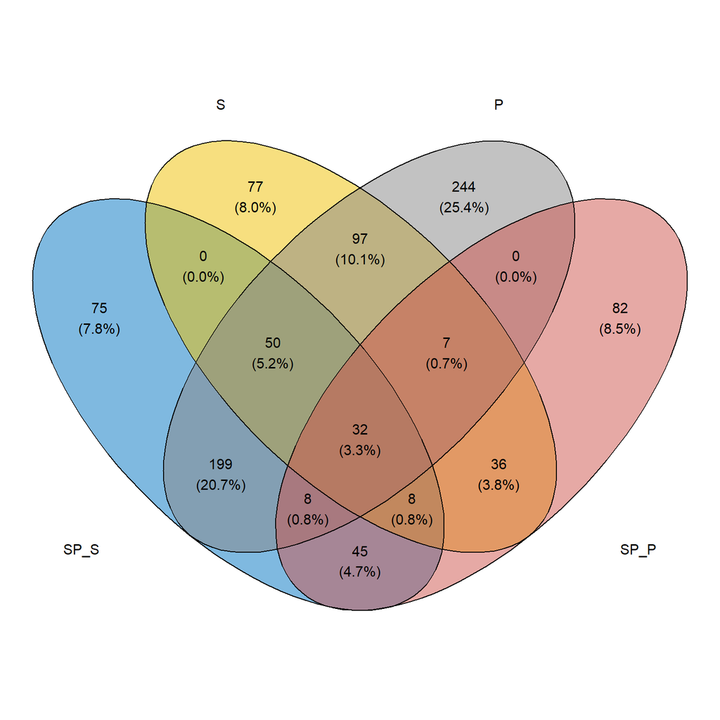

Figure 15: Venn diagram: Uniq_SaPa_up

#### GENES SPECIFICALLY DOWNREGULATED IN SAPA MIXTURE (SC)

```r
# [{(SaPa vs Salt) ∩ (SaPa vs Para)} \ {(Salt vs Ctrl) U (Para vs Ctrl)}]
Uniq_SaPa_down <- setdiff(intersect(GO_SaPavsPara_SC_down_wo_GRG, GO_SaPavsSalt_SC_down_wo_GRG),
                     union(GO_para_SC_down_wo_GRG, GO_salt_SC_down_wo_GRG))
length(Uniq_SaPa_down)
```

```
## [1] 29
```

```r
#WRITE TABLE
#write.table(Uniq_SaPa_down, file = "COMPILED_DATA/GO_GENE_LISTS_SC/GO_Input_wo_GRG/Uniq_SaPa_SC_down.txt", sep = "\t", na = "NA", row.names = FALSE, col.names = FALSE, quote = FALSE)
Uniq_SaPa_SC_down_des <- Gene_Description_SC[(Gene_Description_SC$SGD_DB_ID %in% as.character(Uniq_SaPa_down)), ]
str(Uniq_SaPa_SC_down_des)
```

```
## 'data.frame':    29 obs. of  6 variables:
##  $ SGD_DB_ID  : chr  "S000000293" "S000000345" "S000000579" "S000000589" ...
##  $ SYS_ID     : chr  "YBR089W" "YBR141C" "YCL074W" "YCL026C-A" ...
##  $ ORG        : chr  "S. cerevisiae" "S. cerevisiae" "S. cerevisiae" "S. cerevisiae" ...
##  $ GENE_SYM   : chr  "\"\"" "BMT2" "\"\"" "FRM2" ...
##  $ NAME       : chr  "\"\"" "Base MethylTransferase of 25S RNA" "\"\"" "Fatty acid Repression Mutant" ...
##  $ DESCRIPTION: chr  "Dubious open reading frame; unlikely to encode a functional protein, based on available experimental and compar"| __truncated__ "Nucleolar S-adenosylmethionine-dependent rRNA methyltransferase; methylates adenine (m1A) of large subunit (LSU"| __truncated__ "Pseudogene: encod…
```

```r
Uniq_SaPa_SC_down_des <- cbind(Uniq_SaPa_SC_down_des,
                             salt_SC[as.character(Uniq_SaPa_SC_down_des$SYS_ID), c(2,6)],
                             para_SC[as.character(Uniq_SaPa_SC_down_des$SYS_ID), c(2,6)],
                             SaPa_SC[as.character(Uniq_SaPa_SC_down_des$SYS_ID), c(2,6)])
#write.table(Uniq_SaPa_SC_down_des, file = "COMPILED_DATA/SET_DIFFERENCE/Uniq_SaPa_SC_down_des.txt", sep = "\t", na = "NA", row.names = FALSE, col.names = TRUE, quote = FALSE)
```

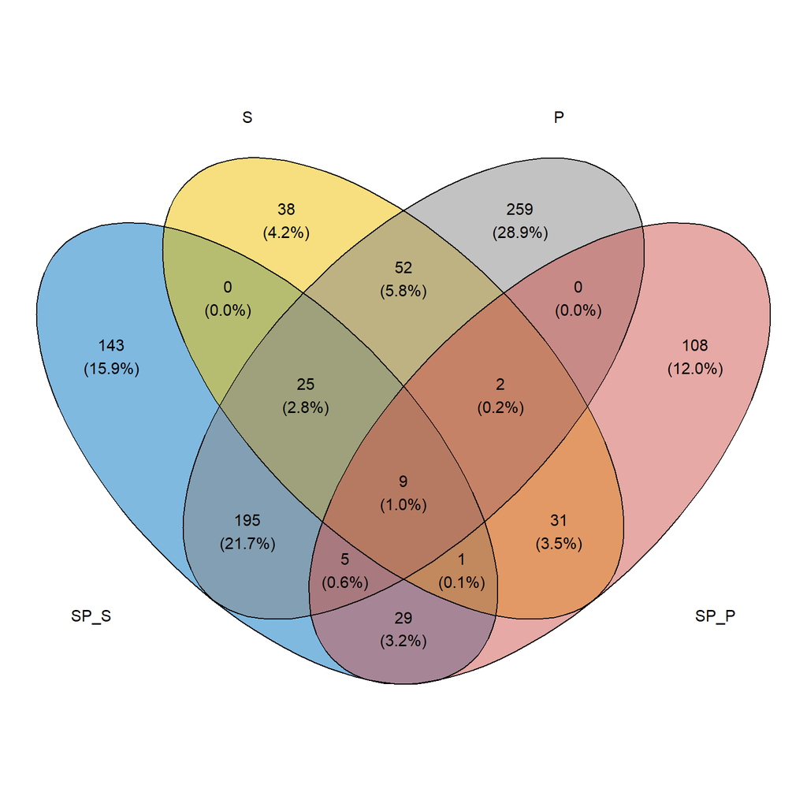

Figure 16: Venn diagram: Uniq_SaPa_down

#### GENES UPREGULATED IN BOTH SAPA vs SALT and SAPA vs PARA COMPARISONS (SC)

```r
# {(SaPa vs Salt) ∩ (SaPa vs Para)}
Intersect_SaPa_up <- intersect(GO_SaPavsPara_SC_up_wo_GRG, GO_SaPavsSalt_SC_up_wo_GRG)
length(Intersect_SaPa_up)
```

```
## [1] 93
```

```r
#write.table(Intersect_SaPa_up, file = "COMPILED_DATA/GO_GENE_LISTS_SC/GO_Input_wo_GRG/Intersect_SaPa_SC_UP.txt", sep = "\t", na = "NA", row.names = FALSE, col.names = FALSE, quote = FALSE)
Intersect_SaPa_up_des <- Gene_Description_SC[(Gene_Description_SC$SGD_DB_ID %in% as.character(Intersect_SaPa_up)), ]
str(Intersect_SaPa_up_des)
```

```
## 'data.frame':    93 obs. of  6 variables:
##  $ SGD_DB_ID  : chr  "S000000070" "S000000197" "S000000210" "S000000249" ...
##  $ SYS_ID     : chr  "YAR015W" "YBL101C" "YBR006W" "YBR045C" ...
##  $ ORG        : chr  "S. cerevisiae" "S. cerevisiae" "S. cerevisiae" "S. cerevisiae" ...
##  $ GENE_SYM   : chr  "ADE1" "ECM21" "UGA2" "GIP1" ...
##  $ NAME       : chr  "ADEnine requiring" "ExtraCellular Mutant" "Utilization of GAba" "Glc7-Interacting Protein" ...
##  $ DESCRIPTION: chr  "N-succinyl-5-aminoimidazole-4-carboxamide ribotide synthetase; required for 'de novo' purine nucleotide biosynt"| __truncated__ "Alpha-arrestin, ubiquitin ligase adaptor for Rsp5p; regulates starvation- and substrate-induced Ub-dependent en"| __truncated__ "Succinate semiald…
```

```r
Intersect_SaPa_up_des <- cbind(Intersect_SaPa_up_des,
                             salt_SC[as.character(Intersect_SaPa_up_des$SYS_ID), c(2,6)],
                             para_SC[as.character(Intersect_SaPa_up_des$SYS_ID), c(2,6)],
                             SaPa_SC[as.character(Intersect_SaPa_up_des$SYS_ID), c(2,6)])
#write.table(Intersect_SaPa_up_des, file = "COMPILED_DATA/SET_DIFFERENCE/Intersect_SaPa_SC_up_des.txt", sep = "\t", na = "NA", row.names = FALSE, col.names = TRUE, quote = FALSE)
```

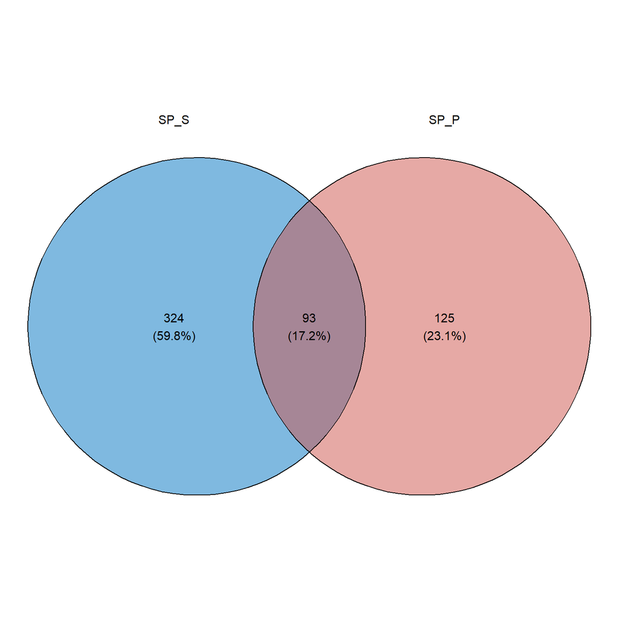

Figure 17: Venn diagram: Intersect_SaPa_up

#### GENES DOWNREGULATED IN BOTH SAPA vs SALT and SAPA vs PARA COMPARISONS (SC)

```r
# {(SaPa vs Salt) ∩ (SaPa vs Para)}
Intersect_SaPa_down <- intersect(GO_SaPavsPara_SC_down_wo_GRG, GO_SaPavsSalt_SC_down_wo_GRG)
length(Intersect_SaPa_down)
```

```
## [1] 44
```

```r
#write.table(Intersect_SaPa_down, file = "COMPILED_DATA/GO_GENE_LISTS_SC/GO_Input_wo_GRG/Intersect_SaPa_SC_down.txt", sep = "\t", na = "NA", row.names = FALSE, col.names = FALSE, quote = FALSE)
Intersect_SaPa_down_des <- Gene_Description_SC[(Gene_Description_SC$SGD_DB_ID %in% as.character(Intersect_SaPa_down)), ]
str(Intersect_SaPa_down_des)
```

```
## 'data.frame':    44 obs. of  6 variables:
##  $ SGD_DB_ID  : chr  "S000000166" "S000000236" "S000000238" "S000000293" ...
##  $ SYS_ID     : chr  "YBL070C" "YBR032W" "YBR034C" "YBR089W" ...
##  $ ORG        : chr  "S. cerevisiae" "S. cerevisiae" "S. cerevisiae" "S. cerevisiae" ...
##  $ GENE_SYM   : chr  "\"\"" "\"\"" "HMT1" "\"\"" ...
##  $ NAME       : chr  "\"\"" "\"\"" "HnRNP MethylTransferase" "\"\"" ...
##  $ DESCRIPTION: chr  "Dubious open reading frame; unlikely to encode a functional protein, based on available experimental and compar"| __truncated__ "Putative protein of unknown function; conserved among S. cerevisiae strains; YBR032W is not an essential gene" "Nuclear SAM-dependent mono- and as…
```

```r
Intersect_SaPa_down_des <- cbind(Intersect_SaPa_down_des,
                             salt_SC[as.character(Intersect_SaPa_down_des$SYS_ID), c(2,6)],
                             para_SC[as.character(Intersect_SaPa_down_des$SYS_ID), c(2,6)],
                             SaPa_SC[as.character(Intersect_SaPa_down_des$SYS_ID), c(2,6)])
#write.table(Intersect_SaPa_down_des, file = "COMPILED_DATA/SET_DIFFERENCE/Intersect_SaPa_SC_down_des.txt", sep = "\t", na = "NA", row.names = FALSE, col.names = TRUE, quote = FALSE)
```

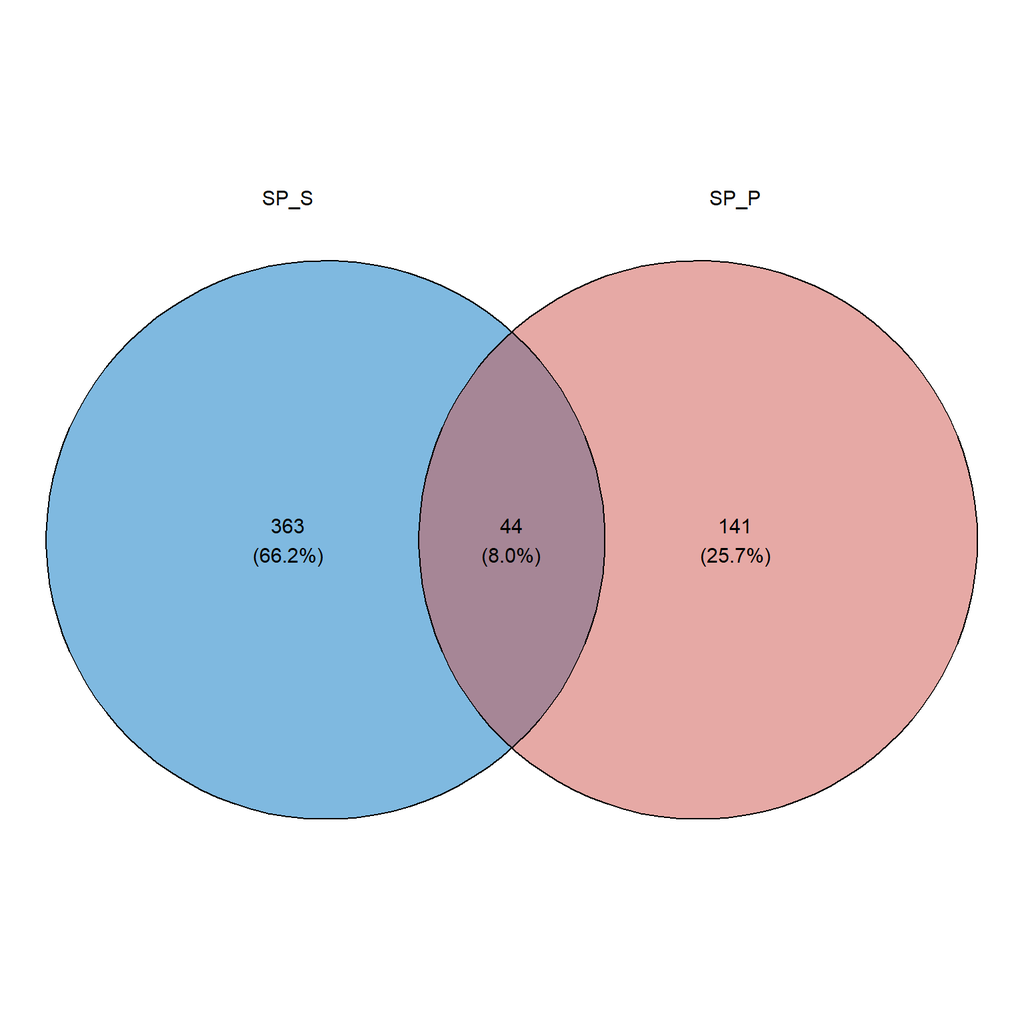

Figure 18: Venn diagram: Intersect_SaPa_down

#### GENES SPECIFICALLY UPREGULATED IN SAPA MIXTURE (DH)

```r
# [{(SaPa vs Salt) ∩ (SaPa vs Para)} \ {(Salt vs Ctrl) U (Para vs Ctrl)}]
Uniq_SaPa_up_DH <- setdiff(intersect(GO_SaPavsPara_DH_up_wo_GRG, GO_SaPavsSalt1_DH_up_wo_GRG),
                     union(GO_para_DH_up_wo_GRG, GO_salt1_DH_up_wo_GRG))
length(Uniq_SaPa_up_DH)
```

```
## [1] 1
```

```r
#WRITE TABLE
#write.table(Uniq_SaPa_up_DH, file = "COMPILED_DATA/GO_GENE_LISTS_DH/GO_Input_wo_GRG/Uniq_SaPa_DH_UP.txt", sep = "\t", na = "NA", row.names = FALSE, col.names = FALSE, quote = FALSE)
Uniq_SaPa_DH_up_des <- Gene_Description_DH[(Gene_Description_DH$SGD_DB_ID %in% as.character(Uniq_SaPa_up_DH)), ]
str(Uniq_SaPa_DH_up_des)
```

```
## 'data.frame':    1 obs. of  18 variables:
##  $ UNIPROT_ENTRY : chr "Q6BI44"
##  $ STATUS        : chr "unreviewed"
##  $ PROTEIN_NAME  : chr "Altered inheritance of mitochondria protein 6"
##  $ ORG           : chr "Debaryomyces hansenii (strain ATCC 36239 / CBS 767 / BCRC 21394 / JCM 1990 / NBRC 0083 / IGC 2968) (Yeast) (Tor"| __truncated__
##  $ PROTEIN_LENGTH: int 341
##  $ SYS_ID        : chr "DEHA2G13552g"
##  $ GENE_SYM      : chr ""
##  $ KEGG_CR       : chr "dha:DEHA2G13552g;"
##  $ GO_ALL        : chr "phosphoric diester hydrolase activity [GO:0008081]; lipid metabolic process [GO:0006629]"
##  $ GO_PROCESS    : chr "lipid metabolic process [GO:0006629]"
##  $ GO_COMPONENT  : chr ""
##  $ GO_FUNCTION   : chr "phosphoric diester hydrolase activity [GO:0008081]"
##  $ SC_SYS_ID     : chr "YDL237W"
##  $ ORTHO_SCORE   : num 0.44
##  $ SGD_DB_ID     : chr "S000002396"
##  $ SC_GENE_SYM   : chr "AIM6"
##  $ NAME          : chr "Altered Inheritance rate of Mitochondria"
##  $ DESCRIPTION   : chr "Protein of unknown function; required for respiratory growth; YDL237W is not an essential gene"
```

```r
Uniq_SaPa_DH_up_des <- cbind(Uniq_SaPa_DH_up_des,
                             salt1_DH[as.character(Uniq_SaPa_DH_up_des$SYS_ID), c(2,6)],
                             para_DH[as.character(Uniq_SaPa_DH_up_des$SYS_ID), c(2,6)],
                             SaPa_DH[as.character(Uniq_SaPa_DH_up_des$SYS_ID), c(2,6)])
#write.table(Uniq_SaPa_DH_up_des, file = "COMPILED_DATA/SET_DIFFERENCE/Uniq_SaPa_DH_UP_des.txt", sep = "\t", na = "NA", row.names = FALSE, col.names = TRUE, quote = FALSE)
```

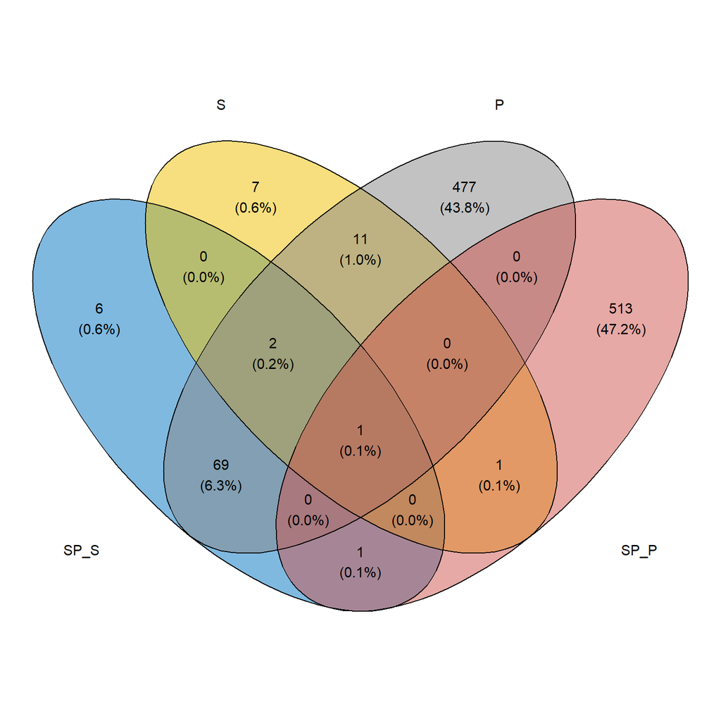

Figure 19: Venn diagram: Uniq_SaPa_up_DH

#### GENES SPECIFICALLY DOWNREGULATED IN SAPA MIXTURE (DH)

```r
# [{(SaPa vs Salt) ∩ (SaPa vs Para)} \ {(Salt vs Ctrl) U (Para vs Ctrl)}]
Uniq_SaPa_down_DH <- setdiff(intersect(GO_SaPavsPara_DH_down_wo_GRG, GO_SaPavsSalt1_DH_down_wo_GRG),
                     union(GO_para_DH_down_wo_GRG, GO_salt1_DH_down_wo_GRG))
length(Uniq_SaPa_down_DH)
```

```
## [1] 14
```

```r
#WRITE TABLE
#write.table(Uniq_SaPa_down_DH, file = "COMPILED_DATA/GO_GENE_LISTS_DH/GO_Input_wo_GRG/Uniq_SaPa_DH_down.txt", sep = "\t", na = "NA", row.names = FALSE, col.names = FALSE, quote = FALSE)
Uniq_SaPa_DH_down_des <- Gene_Description_DH[(Gene_Description_DH$SGD_DB_ID %in% as.character(Uniq_SaPa_down_DH)), ]
str(Uniq_SaPa_DH_down_des)
```

```
## 'data.frame':    14 obs. of  18 variables:
##  $ UNIPROT_ENTRY : chr  "Q6BL58" "Q6BVH4" "Q6BJG4" "B5RTT3" ...
##  $ STATUS        : chr  "reviewed" "reviewed" "reviewed" "unreviewed" ...
##  $ PROTEIN_NAME  : chr  "Exportin-T (Exportin(tRNA)) (Karyopherin-beta) (tRNA exportin)" "General transcription and DNA repair factor IIH subunit TFB5 (TFIIH subunit TFB5) (RNA polymerase II transcript"| __truncated__ "Carbamoyl-phosphate synthase arginine-specific small chain (CPS-A) (EC 6.3.5.5…
##  $ ORG           : chr  "Debaryomyces hansenii (strain ATCC 36239 / CBS 767 / BCRC 21394 / JCM 1990 / NBRC 0083 / IGC 2968) (Yeast) (Tor"| __truncated__ "Debaryomyces hansenii (strain ATCC 36239 / CBS 767 / BCRC 21394 / JCM 1990 / NBRC 0083 / IGC 2968) (Yeast) (Tor"| __truncated__ "Debaryomyces h…
##  $ PROTEIN_LENGTH: int  1000 69 429 645 800 427 798 579 310 785 ...
##  $ SYS_ID        : chr  "DEHA2F16192g" "DEHA2C02662g" "DEHA2G02618g" "DEHA2E02596g" ...
##  $ GENE_SYM      : chr  "LOS1" "TFB5" "CPA1" "" ...
##  $ KEGG_CR       : chr  "dha:DEHA2F16192g;" "dha:DEHA2C02662g;" "dha:DEHA2G02618g;" "dha:DEHA2E02596g;" ...
##  $ GO_ALL        : chr  "cytoplasm [GO:0005737]; nuclear matrix [GO:0016363]; small GTPase binding [GO:0031267]; tRNA binding [GO:000004"| __truncated__ "cytosol [GO:0005829]; transcription factor TFIIH core complex [GO:0000439]; transcription factor TFIIH holo com"| __truncated__ "carbamoyl-phos…
##  $ GO_PROCESS    : chr  "tRNA processing [GO:0008033]; tRNA re-export from nucleus [GO:0071528]" "nucleotide-excision repair [GO:0006289]; phosphorylation of RNA polymerase II C-terminal domain [GO:0070816]; t"| __truncated__ "'de novo' pyrimidine nucleobase biosynthetic process [GO:0006207]; arg…
##  $ GO_COMPONENT  : chr  "cytoplasm [GO:0005737]; nuclear matrix [GO:0016363]" "cytosol [GO:0005829]; transcription factor TFIIH core complex [GO:0000439]; transcription factor TFIIH holo com"| __truncated__ "carbamoyl-phosphate synthase complex [GO:0005951]" "integral component of membrane [GO:00…
##  $ GO_FUNCTION   : chr  "small GTPase binding [GO:0031267]; tRNA binding [GO:0000049]" "" "ATP binding [GO:0005524]; carbamoyl-phosphate synthase (glutamine-hydrolyzing) activity [GO:0004088]" "transmembrane transporter activity [GO:0022857]" ...
##  $ SC_SYS_ID     : chr  "YKL205W" "YDR079C-A" "YOR303W" "YOL158C" ...
##  $ ORTHO_SCORE   : num  1.062 0.194 1.387 0.424 0.081 ...
##  $ SGD_DB_ID     : chr  "S000001688" "S000007603" "S000005829" "S000005518" ...
##  $ SC_GENE_SYM   : chr  "LOS1" "TFB5" "CPA1" "ENB1" ...
##  $ NAME          : chr  "Loss Of Suppression" "\"\"" "Carbamyl Phosphate synthetase A" "ENteroBactin" ...
##  $ DESCRIPTION   : chr  "Nuclear pore protein; involved in nuclear export of pre-tRNA and in re-export of mature tRNAs after their retro"| __truncated__ "Component of RNA polymerase II general transcription factor TFIIH; involved in transcription initiation and in "| __truncated__ "Small subunit …
```

```r
Uniq_SaPa_DH_down_des <- cbind(Uniq_SaPa_DH_down_des,
                             salt1_DH[as.character(Uniq_SaPa_DH_down_des$SYS_ID), c(2,6)],
                             para_DH[as.character(Uniq_SaPa_DH_down_des$SYS_ID), c(2,6)],
                             SaPa_DH[as.character(Uniq_SaPa_DH_down_des$SYS_ID), c(2,6)])
#write.table(Uniq_SaPa_DH_down_des, file = "COMPILED_DATA/SET_DIFFERENCE/Uniq_SaPa_DH_down_des.txt", sep = "\t", na = "NA", row.names = FALSE, col.names = TRUE, quote = FALSE)
```

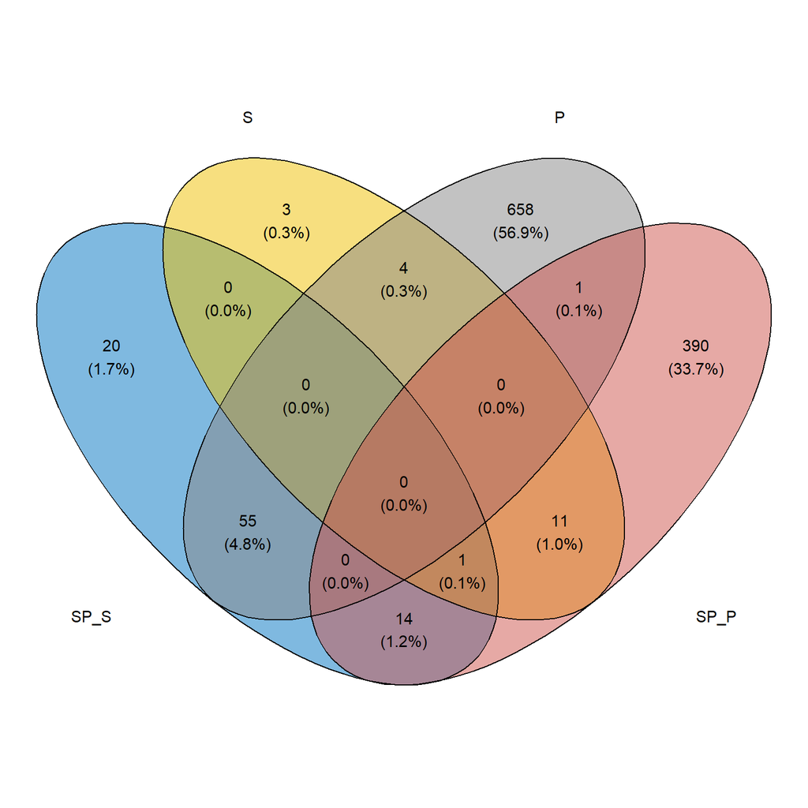

Figure 20: Venn diagram: Uniq_SaPa_down_DH

#### GENES UPREGULATED IN BOTH SAPA vs SALT and SAPA vs PARA COMPARISONS (DH)

```r
# {(SaPa vs Salt) ∩ (SaPa vs Para)}
Intersect_SaPa_up_DH <- intersect(GO_SaPavsPara_DH_up_wo_GRG, GO_SaPavsSalt1_DH_up_wo_GRG)
length(Intersect_SaPa_up_DH)
```

```
## [1] 3
```

```r
write.table(Intersect_SaPa_up_DH, file = "COMPILED_DATA/GO_GENE_LISTS_DH/GO_Input_wo_GRG/Intersect_SaPa_DH_UP.txt", sep = "\t", na = "NA", row.names = FALSE, col.names = FALSE, quote = FALSE)
Intersect_SaPa_up_des_DH <- Gene_Description_DH[(Gene_Description_DH$SGD_DB_ID %in% as.character(na.omit(Intersect_SaPa_up_DH))), ]
str(Intersect_SaPa_up_des_DH)
```

```
## 'data.frame':    6 obs. of  18 variables:
##  $ UNIPROT_ENTRY : chr  "Q6BI44" "B5RSX2" "B5RUI0" "Q6BN52" ...
##  $ STATUS        : chr  "unreviewed" "unreviewed" "unreviewed" "unreviewed" ...
##  $ PROTEIN_NAME  : chr  "Altered inheritance of mitochondria protein 6" "DEHA2B16610p" "DEHA2F16478p" "DEHA2F00154p" ...
##  $ ORG           : chr  "Debaryomyces hansenii (strain ATCC 36239 / CBS 767 / BCRC 21394 / JCM 1990 / NBRC 0083 / IGC 2968) (Yeast) (Tor"| __truncated__ "Debaryomyces hansenii (strain ATCC 36239 / CBS 767 / BCRC 21394 / JCM 1990 / NBRC 0083 / IGC 2968) (Yeast) (Tor"| __truncated__ "Debaryomyces h…
##  $ PROTEIN_LENGTH: int  341 1508 1500 1099 1463 1481
##  $ SYS_ID        : chr  "DEHA2G13552g" "DEHA2B16610g" "DEHA2F16478g" "DEHA2F00154g" ...
##  $ GENE_SYM      : chr  "" "" "" "" ...
##  $ KEGG_CR       : chr  "dha:DEHA2G13552g;" "dha:DEHA2B16610g;" "dha:DEHA2F16478g;" "dha:DEHA2F00154g;" ...
##  $ GO_ALL        : chr  "phosphoric diester hydrolase activity [GO:0008081]; lipid metabolic process [GO:0006629]" "integral component of membrane [GO:0016021]; ATP binding [GO:0005524]; ATPase-coupled transmembrane transporter"| __truncated__ "integral component of membrane [GO:0016021]; ATP bin…
##  $ GO_PROCESS    : chr  "lipid metabolic process [GO:0006629]" "xenobiotic detoxification by transmembrane export across the plasma membrane [GO:1990961]" "xenobiotic detoxification by transmembrane export across the plasma membrane [GO:1990961]" "" ...
##  $ GO_COMPONENT  : chr  "" "integral component of membrane [GO:0016021]" "integral component of membrane [GO:0016021]" "integral component of membrane [GO:0016021]" ...
##  $ GO_FUNCTION   : chr  "phosphoric diester hydrolase activity [GO:0008081]" "ATPase-coupled transmembrane transporter activity [GO:0042626]; ATP binding [GO:0005524]" "ATPase-coupled transmembrane transporter activity [GO:0042626]; ATP binding [GO:0005524]" "ATPase-coupled transmembrane transpor…
##  $ SC_SYS_ID     : chr  "YDL237W" "YOR328W" "YOR328W" "YOR328W" ...
##  $ ORTHO_SCORE   : num  0.44 2.92 2.92 2.92 2.92 ...
##  $ SGD_DB_ID     : chr  "S000002396" "S000005855" "S000005855" "S000005855" ...
##  $ SC_GENE_SYM   : chr  "AIM6" "PDR10" "PDR10" "PDR10" ...
##  $ NAME          : chr  "Altered Inheritance rate of Mitochondria" "Pleiotropic Drug Resistance" "Pleiotropic Drug Resistance" "Pleiotropic Drug Resistance" ...
##  $ DESCRIPTION   : chr  "Protein of unknown function; required for respiratory growth; YDL237W is not an essential gene" "ATP-binding cassette (ABC) transporter; multidrug transporter involved in the pleiotropic drug resistance netwo"| __truncated__ "ATP-binding cassette (ABC) transporter; multid…
```

```r
Intersect_SaPa_up_des_DH <- cbind(Intersect_SaPa_up_des_DH,
                             salt1_DH[as.character(Intersect_SaPa_up_des_DH$SYS_ID), c(2,6)],
                             para_DH[as.character(Intersect_SaPa_up_des_DH$SYS_ID), c(2,6)],
                             SaPa_DH[as.character(Intersect_SaPa_up_des_DH$SYS_ID), c(2,6)])
#write.table(Intersect_SaPa_up_des_DH, file = "COMPILED_DATA/SET_DIFFERENCE/Intersect_SaPa_DH_up_des.txt", sep = "\t", na = "NA", row.names = FALSE, col.names = TRUE, quote = FALSE)
```

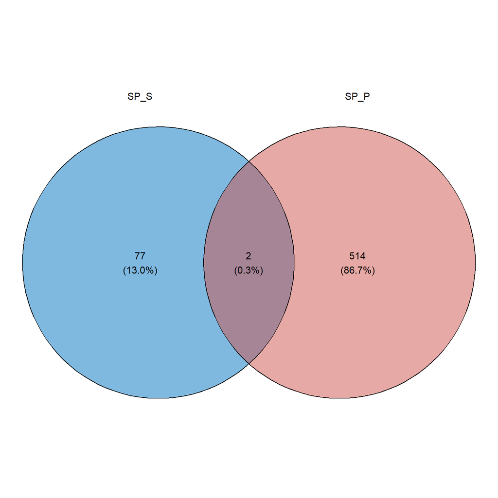

Figure 21: Venn diagram: Intersect_SaPa_up_DH

#### GENES DOWNREGULATED IN BOTH SAPA vs SALT and SAPA vs PARA COMPARISONS (DH)

```r
# {(SaPa vs Salt) ∩ (SaPa vs Para)}
Intersect_SaPa_down_DH <- intersect(GO_SaPavsPara_DH_down_wo_GRG, GO_SaPavsSalt1_DH_down_wo_GRG)
length(Intersect_SaPa_down_DH)
```

```
## [1] 16
```

```r
#write.table(Intersect_SaPa_down_DH, file = "COMPILED_DATA/GO_GENE_LISTS_DH/GO_Input_wo_GRG/Intersect_SaPa_DH_down.txt", sep = "\t", na = "NA", row.names = FALSE, col.names = FALSE, quote = FALSE)
Intersect_SaPa_down_des_DH <- Gene_Description_DH[(Gene_Description_DH$SGD_DB_ID %in% as.character(na.omit(Intersect_SaPa_down_DH))), ]
str(Intersect_SaPa_down_des_DH)
```

```
## 'data.frame':    15 obs. of  18 variables:
##  $ UNIPROT_ENTRY : chr  "Q6BL58" "Q6BVH4" "Q6BJG4" "B5RTT3" ...
##  $ STATUS        : chr  "reviewed" "reviewed" "reviewed" "unreviewed" ...
##  $ PROTEIN_NAME  : chr  "Exportin-T (Exportin(tRNA)) (Karyopherin-beta) (tRNA exportin)" "General transcription and DNA repair factor IIH subunit TFB5 (TFIIH subunit TFB5) (RNA polymerase II transcript"| __truncated__ "Carbamoyl-phosphate synthase arginine-specific small chain (CPS-A) (EC 6.3.5.5…
##  $ ORG           : chr  "Debaryomyces hansenii (strain ATCC 36239 / CBS 767 / BCRC 21394 / JCM 1990 / NBRC 0083 / IGC 2968) (Yeast) (Tor"| __truncated__ "Debaryomyces hansenii (strain ATCC 36239 / CBS 767 / BCRC 21394 / JCM 1990 / NBRC 0083 / IGC 2968) (Yeast) (Tor"| __truncated__ "Debaryomyces h…
##  $ PROTEIN_LENGTH: int  1000 69 429 645 800 427 798 579 310 785 ...
##  $ SYS_ID        : chr  "DEHA2F16192g" "DEHA2C02662g" "DEHA2G02618g" "DEHA2E02596g" ...
##  $ GENE_SYM      : chr  "LOS1" "TFB5" "CPA1" "" ...
##  $ KEGG_CR       : chr  "dha:DEHA2F16192g;" "dha:DEHA2C02662g;" "dha:DEHA2G02618g;" "dha:DEHA2E02596g;" ...
##  $ GO_ALL        : chr  "cytoplasm [GO:0005737]; nuclear matrix [GO:0016363]; small GTPase binding [GO:0031267]; tRNA binding [GO:000004"| __truncated__ "cytosol [GO:0005829]; transcription factor TFIIH core complex [GO:0000439]; transcription factor TFIIH holo com"| __truncated__ "carbamoyl-phos…
##  $ GO_PROCESS    : chr  "tRNA processing [GO:0008033]; tRNA re-export from nucleus [GO:0071528]" "nucleotide-excision repair [GO:0006289]; phosphorylation of RNA polymerase II C-terminal domain [GO:0070816]; t"| __truncated__ "'de novo' pyrimidine nucleobase biosynthetic process [GO:0006207]; arg…
##  $ GO_COMPONENT  : chr  "cytoplasm [GO:0005737]; nuclear matrix [GO:0016363]" "cytosol [GO:0005829]; transcription factor TFIIH core complex [GO:0000439]; transcription factor TFIIH holo com"| __truncated__ "carbamoyl-phosphate synthase complex [GO:0005951]" "integral component of membrane [GO:00…
##  $ GO_FUNCTION   : chr  "small GTPase binding [GO:0031267]; tRNA binding [GO:0000049]" "" "ATP binding [GO:0005524]; carbamoyl-phosphate synthase (glutamine-hydrolyzing) activity [GO:0004088]" "transmembrane transporter activity [GO:0022857]" ...
##  $ SC_SYS_ID     : chr  "YKL205W" "YDR079C-A" "YOR303W" "YOL158C" ...
##  $ ORTHO_SCORE   : num  1.062 0.194 1.387 0.424 0.081 ...
##  $ SGD_DB_ID     : chr  "S000001688" "S000007603" "S000005829" "S000005518" ...
##  $ SC_GENE_SYM   : chr  "LOS1" "TFB5" "CPA1" "ENB1" ...
##  $ NAME          : chr  "Loss Of Suppression" "\"\"" "Carbamyl Phosphate synthetase A" "ENteroBactin" ...
##  $ DESCRIPTION   : chr  "Nuclear pore protein; involved in nuclear export of pre-tRNA and in re-export of mature tRNAs after their retro"| __truncated__ "Component of RNA polymerase II general transcription factor TFIIH; involved in transcription initiation and in "| __truncated__ "Small subunit …
```

```r
Intersect_SaPa_down_des_DH <- cbind(Intersect_SaPa_down_des_DH,
                             salt1_DH[as.character(Intersect_SaPa_down_des_DH$SYS_ID), c(2,6)],
                             para_DH[as.character(Intersect_SaPa_down_des_DH$SYS_ID), c(2,6)],
                             SaPa_DH[as.character(Intersect_SaPa_down_des_DH$SYS_ID), c(2,6)])
#write.table(Intersect_SaPa_down_des_DH, file = "COMPILED_DATA/SET_DIFFERENCE/Intersect_SaPa_DHdown_des_DH.txt", sep = "\t", na = "NA", row.names = FALSE, col.names = TRUE, quote = FALSE)
```

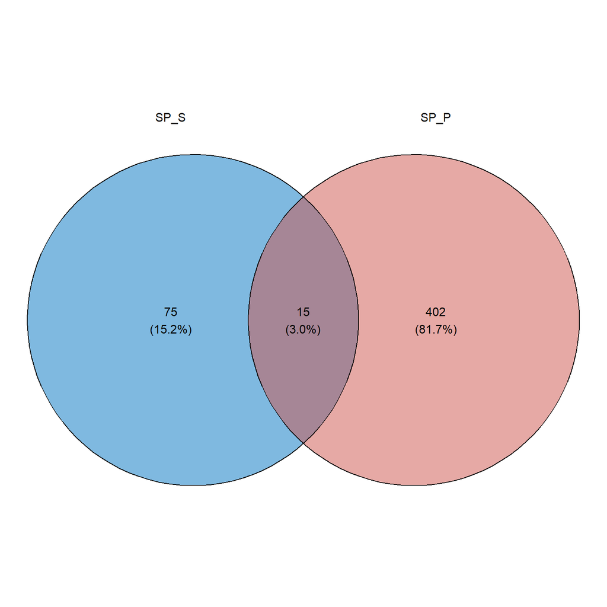

Figure 22: Venn diagram: Intersect_SaPa_down_DH

#### GENES SPECIFICALLY UPREGULATED IN SARA MIXTURE (SC)

```r
# [{(SaRa vs Salt) ∩ (SaRa vs RaPa)} \ {(Salt vs Ctrl) U (RaPa vs Ctrl)}]
Uniq_SaRa_up <- setdiff(intersect(GO_SaRavsRapa_SC_up_wo_GRG, GO_SaRavsSalt_SC_up_wo_GRG),
                     union(GO_rapa_SC_up_wo_GRG, GO_salt_SC_up_wo_GRG))
length(Uniq_SaRa_up)
```

```
## [1] 57
```

```r
#WRITE TABLE
#write.table(Uniq_SaRa_up, file = "COMPILED_DATA/GO_GENE_LISTS_SC/GO_Input_wo_GRG/Uniq_SaRa_SC_UP.txt", sep = "\t", na = "NA", row.names = FALSE, col.names = FALSE, quote = FALSE)
Uniq_SaRa_SC_up_des <- Gene_Description_SC[(Gene_Description_SC$SGD_DB_ID %in% as.character(Uniq_SaRa_up)), ]
str(Uniq_SaRa_SC_up_des)
```

```
## 'data.frame':    57 obs. of  6 variables:
##  $ SGD_DB_ID  : chr  "S000000182" "S000000280" "S000000417" "S000000500" ...
##  $ SYS_ID     : chr  "YBL086C" "YBR076W" "YBR213W" "YBR296C" ...
##  $ ORG        : chr  "S. cerevisiae" "S. cerevisiae" "S. cerevisiae" "S. cerevisiae" ...
##  $ GENE_SYM   : chr  "\"\"" "ECM8" "MET8" "PHO89" ...
##  $ NAME       : chr  "\"\"" "ExtraCellular Mutant" "METhionine requiring" "PHOsphate metabolism" ...
##  $ DESCRIPTION: chr  "Protein of unknown function; green fluorescent protein (GFP)-fusion protein localizes to the cell periphery" "Non-essential protein of unknown function" "Bifunctional dehydrogenase and ferrochelatase; involved in the biosynthesis of siroheme, a prosthetic group use"| __trunc…
```

```r
Uniq_SaRa_SC_up_des <- cbind(Uniq_SaRa_SC_up_des,
                             salt_SC[as.character(Uniq_SaRa_SC_up_des$SYS_ID), c(2,6)],
                             rapa_SC[as.character(Uniq_SaRa_SC_up_des$SYS_ID), c(2,6)],
                             SaRa_SC[as.character(Uniq_SaRa_SC_up_des$SYS_ID), c(2,6)])
#write.table(Uniq_SaRa_SC_up_des, file = "COMPILED_DATA/SET_DIFFERENCE/Uniq_SaRa_SC_up_des.txt", sep = "\t", na = "NA", row.names = FALSE, col.names = TRUE, quote = FALSE)
```

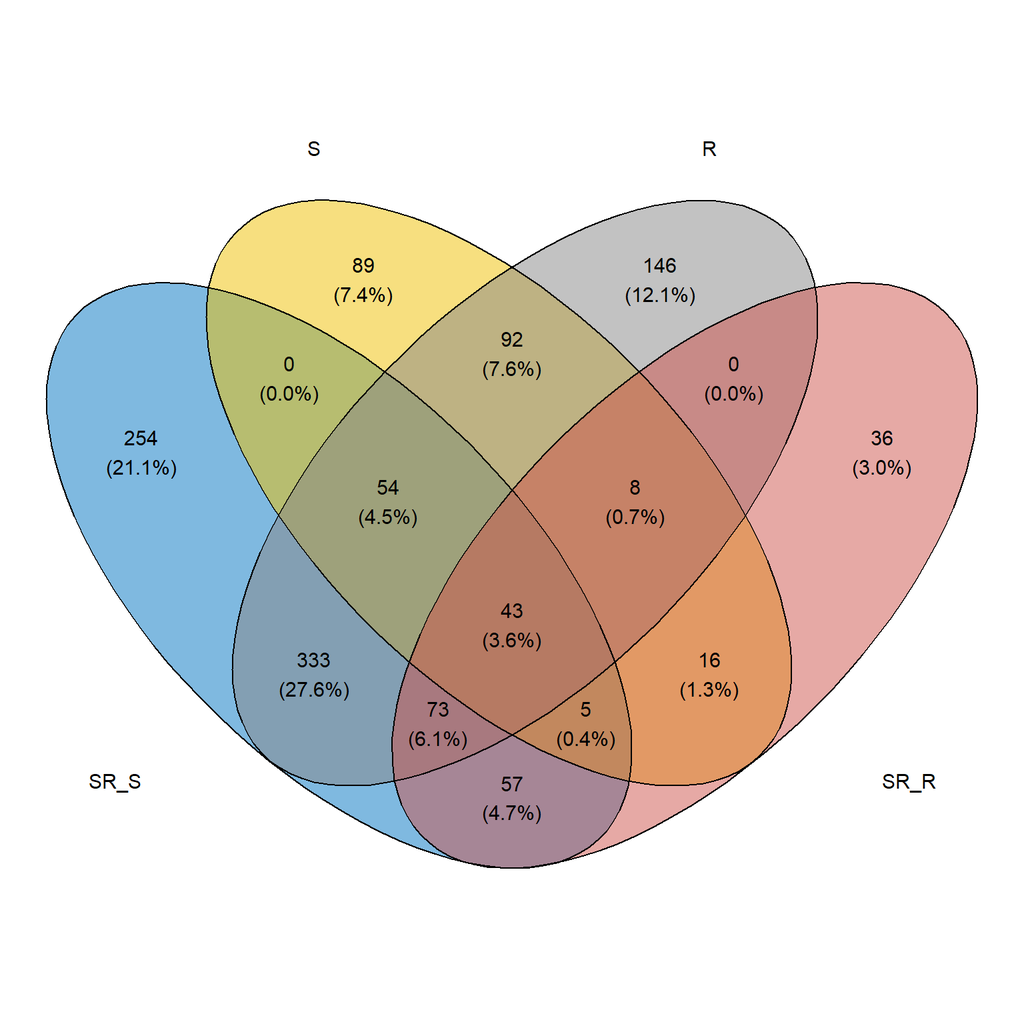

Figure 23: Venn diagram: Uniq_SaRa_up

#### GENES SPECIFICALLY DOWNREGULATED IN SARA MIXTURE (SC)

```r
# [{(SaRa vs Salt) ∩ (SaRa vs Rapa)} \ {(Salt vs Ctrl) U (Rapa vs Ctrl)}]
Uniq_SaRa_down <- setdiff(intersect(GO_SaRavsRapa_SC_down_wo_GRG, GO_SaRavsSalt_SC_down_wo_GRG),
                     union(GO_rapa_SC_down_wo_GRG, GO_salt_SC_down_wo_GRG))
length(Uniq_SaRa_down)
```

```
## [1] 81
```

```r
#WRITE TABLE
#write.table(Uniq_SaRa_down, file = "COMPILED_DATA/GO_GENE_LISTS_SC/GO_Input_wo_GRG/Uniq_SaRa_SC_down.txt", sep = "\t", na = "NA", row.names = FALSE, col.names = FALSE, quote = FALSE)
Uniq_SaRa_SC_down_des <- Gene_Description_SC[(Gene_Description_SC$SGD_DB_ID %in% as.character(Uniq_SaRa_down)), ]
str(Uniq_SaRa_SC_down_des)
```

```
## 'data.frame':    81 obs. of  6 variables:
##  $ SGD_DB_ID  : chr  "S000000023" "S000000149" "S000000177" "S000000282" ...
##  $ SYS_ID     : chr  "YAL025C" "YBL053W" "YBL081W" "YBR078W" ...
##  $ ORG        : chr  "S. cerevisiae" "S. cerevisiae" "S. cerevisiae" "S. cerevisiae" ...
##  $ GENE_SYM   : chr  "MAK16" "\"\"" "\"\"" "ECM33" ...
##  $ NAME       : chr  "MAintenance of Killer" "\"\"" "\"\"" "ExtraCellular Mutant" ...
##  $ DESCRIPTION: chr  "Essential nuclear protein; constituent of 66S pre-ribosomal particles; required for maturation of 25S and 5.8S "| __truncated__ "Dubious open reading frame; unlikely to encode a functional protein, based on available experimental and compar"| __truncated__ "Non-essential pro…
```

```r
Uniq_SaRa_SC_down_des <- cbind(Uniq_SaRa_SC_down_des,
                             salt_SC[as.character(Uniq_SaRa_SC_down_des$SYS_ID), c(2,6)],
                             rapa_SC[as.character(Uniq_SaRa_SC_down_des$SYS_ID), c(2,6)],
                             SaRa_SC[as.character(Uniq_SaRa_SC_down_des$SYS_ID), c(2,6)])
#write.table(Uniq_SaRa_SC_down_des, file = "COMPILED_DATA/SET_DIFFERENCE/Uniq_SaRa_SC_down_des.txt", sep = "\t", na = "NA", row.names = FALSE, col.names = TRUE, quote = FALSE)
```

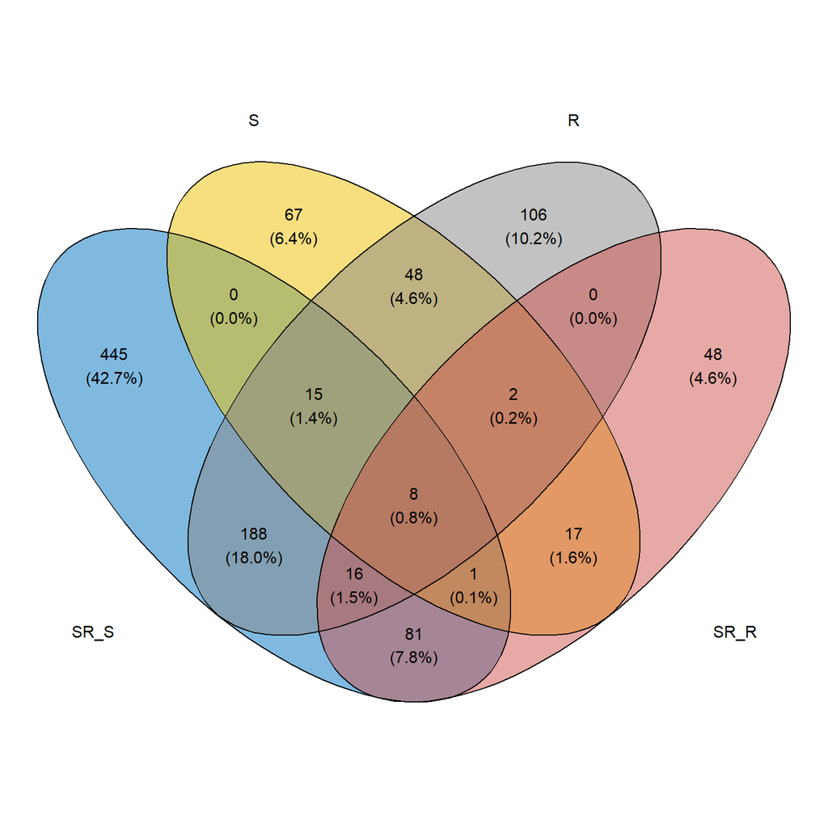

Figure 24: Venn diagram: Uniq_SaRa_down